# Mixture Models with JAGS

```r
# Core packages — install if needed:
# install.packages(c("rjags","coda","ggplot2","ggtern","mvtnorm","MASS",
#                     "tidyverse","patchwork","loo","scales"))
library(rjags)
library(coda)
library(ggplot2)
library(mvtnorm)
library(MASS)
library(tidyverse)
library(patchwork)
library(loo)         # WAIC and PSIS-LOO model comparison

theme_set(theme_bw(base_size = 13))
```

# Why mixture models?

Most of the statistical models we have met so far assume that the data come from *one* well-behaved distribution: one Gaussian, one Gamma, one Weibull. That single-population assumption is convenient, but the real world rarely cooperates. Heights of adults are bimodal because the population mixes men and women; distributions of household income have a heavy upper tail because the population mixes earners from very different economic strata; reaction times in psychology experiments often look like two superimposed bells because subjects switch between fast and slow cognitive strategies. In all of these situations the data generating mechanism is more honestly described as a **mixture** of several simpler distributions, one per hidden subpopulation.

A finite **mixture model** is precisely that idea written down as a probability density:

$$f(y) \;=\; \sum_{h=1}^{H} p_h\, f_h(y),
\qquad p_h \ge 0, \quad \sum_h p_h = 1.$$

Each $f_h$ is the density of a subpopulation (a “**component**”, or a “**cluster**”), and the weights $p_h$ tell us what fraction of the overall population each subpopulation contributes. Inference splits naturally into three questions, and we will meet all of them:

1. **Density estimation.** What does $f$ as a whole look like? Even when the components are not interpretable as real groups, a mixture is a remarkably flexible *semi-parametric* density estimator — a small number of Gaussians, Betas or Gammas can approximate strikingly complex shapes.
2. **Clustering.** Which observations come from which component? This is the *unsupervised learning* problem: discover groups in unlabelled data. The mixture model gives a fully probabilistic answer — a posterior probability that observation $i$ belongs to cluster $h$ — which is strictly more informative than the hard assignments produced by classical algorithms like $K$-means.
3. **Model selection.** How many components $H$ does the data actually support? This is the genuinely hard question; we will tackle it with the same information-criteria machinery (WAIC, PSIS-LOO) that we used to compare parametric survival families.

The lecture is organised around three worked examples that together cover the ideas you need:

- A motivating two-dimensional **simulated Gaussian mixture** where we know the truth, to introduce the latent-allocation formulation and see clustering in action.
- The classic **galaxy** dataset, where we fit a univariate Gaussian mixture and use WAIC / PSIS-LOO to ask *how many clusters* the data support — the central, hard question of mixture modelling.
- A real-data case study on **fossil-fuel shares in 2015 vs 2024**, where the data live on $[0,1]$ and we use a **Beta mixture** — illustrating both that the choice of component family must match the support of the data, and that a mixture analysis recovers cluster-level structural changes that a single summary statistic or a single Beta cannot see.

Before we touch any data we need one piece of theoretical equipment — the **Dirichlet distribution**, the natural probability distribution over the vector of mixing weights $(p_1, \dots, p_H)$. We introduce it next, after a brief detour through classical clustering.

# Helper functions

Before diving into the statistics, we collect a small toolbox that every example will reuse: a routine for the Gelman–Rubin convergence diagnostic, a routine to pull the monitored pointwise log-likelihood out of the MCMC output in the matrix shape the `loo` package wants, a small formatter for WAIC tables, and a generic wrapper that compiles, burns in and samples a JAGS mixture model with sensible defaults. Keeping all the plumbing in one place lets each model section focus on the statistical content.

```r
# --- Convergence -----------------------------------------------------------

# Gelman-Rubin diagnostic table (R-hat < 1.1 indicates convergence)
gr_table <- function(mcmc_list) {
  gr <- gelman.diag(mcmc_list, multivariate = FALSE)$psrf
  knitr::kable(round(gr, 4),
               caption = "Gelman–Rubin R-hat (values < 1.1 indicate convergence)")
}

# --- Log-likelihood / information criteria ---------------------------------

# Stack the monitored log_lik[i] columns across chains into an S x n matrix,
# exactly as in the survival notebook. `loo::waic` / `loo::loo` consume it.
extract_ll <- function(samps) {
  do.call(rbind, lapply(samps, function(ch)
    ch[, grep("^log_lik\\[", colnames(ch)), drop = FALSE]))
}

# One row of a WAIC comparison table
ic_row <- function(w, nm) {
  e <- w$estimates
  data.frame(Model = nm,
             ELPD  = round(e["elpd_waic", "Estimate"], 1),
             p_eff = round(e["p_waic",    "Estimate"], 1),
             WAIC  = round(e["waic",      "Estimate"], 1),
             SE    = round(e["waic",      "SE"],       1))
}

# --- Generic finite-mixture fitter -----------------------------------------
# Compiles, burns in and samples a JAGS mixture model with the standard
# settings, and returns the coda samples. `model_string` must use the data
# fed through `data_extra` plus the components count H.
fit_mixture <- function(model_string, dataList,
                        variable.names,
                        burn = 5000, n.iter = 10000,
                        thin = 5, n.chains = 3, n.adapt = 2000,
                        inits = NULL) {
  model <- jags.model(textConnection(model_string),
                      data     = dataList,
                      inits    = inits,
                      n.chains = n.chains,
                      n.adapt  = n.adapt,
                      quiet    = TRUE)
  update(model, n.iter = burn)
  coda.samples(model,
               variable.names = variable.names,
               n.iter = n.iter,
               thin   = thin)
}
```

# From clustering to mixtures

## What is clustering?

**Clustering** is the prototypical *unsupervised* learning task: given a sample of data points but no labels, partition them into natural groups — called **clusters** — such that points in the same group are as similar as possible and points in different groups are as different as possible. There is no teacher to tell us the correct answer; the structure has to be discovered from the data themselves.

A classical example is Fisher’s iris dataset. Below we look at just two features (petal length and petal width) of 150 flowers from three species:

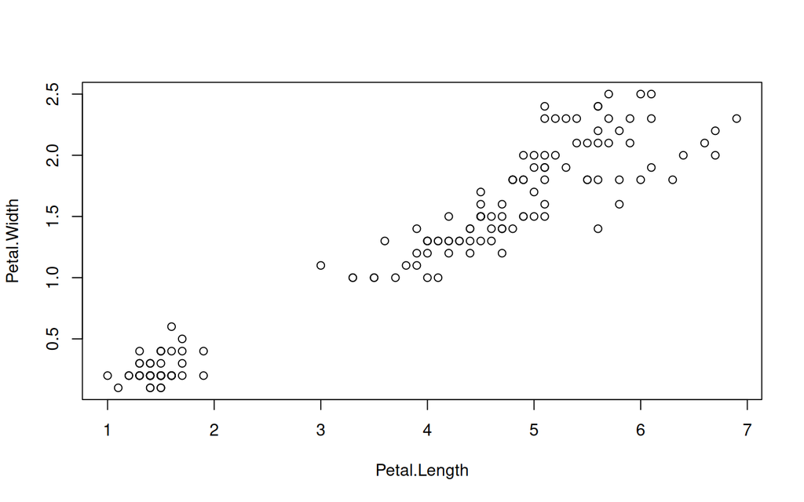

```r
data = iris[,3:4]
plot(data)
```

Points within each cloud are close together — *cohesion* — while the clouds are well separated from each other — *separation*. Cohesion and separation are the two informal criteria that “clustering” is supposed to optimise.

The Bayesian way to formalise this task is to write a **generative probability model** for the data that *includes* the cluster structure, and then to do posterior inference on the unknowns. That model is the **finite mixture model**, and it gives us everything we want from a serious clustering method:

- **Soft, probabilistic assignments.** Each observation gets a posterior *probability* of belonging to each cluster, not a single hard label — uncertain points get uncertain labels, as they should.
- **Flexible cluster shapes.** We can choose any parametric family for the components (Gaussian with full covariance, Beta on the unit interval, Gamma for positive data, …), so the geometry of the clusters is whatever the data call for.
- **A full likelihood.** Because the model is a proper probability distribution, we can put priors on its parameters, predict the cluster of a *new* observation, and — crucially — compare models with different numbers of clusters $K$ in a principled way (WAIC, PSIS-LOO).
- **$K$ becomes an answer, not an input.** Instead of guessing the number of clusters we *fit* several values of $K$ and let an information criterion rank them.

## The generative story

Think of the data as being produced as follows. Nature has $H$ subpopulations, each with its own distribution $f_h(\cdot \mid \theta_h)$, and a vector of proportions $(p_1, \dots, p_H)$ on the $H$ subpopulations. To produce observation $y_i$, nature first **rolls an $H$-sided die** with probabilities $(p_1, \dots, p_H)$, obtaining a latent label $z_i \in \{1, \dots, H\}$, and then **draws $y_i$ from component $z_i$**:

$$z_i \mid p \;\sim\; \mathcal{C}at(p_1, \dots, p_H),
\qquad
y_i \mid z_i, \theta \;\sim\; f_{z_i}(y_i \mid \theta_{z_i}).$$

We observe the $y_i$’s but not the $z_i$’s — the labels are **latent**. Marginalising over $z_i$ gives back the mixture density

$$f(y_i \mid p, \theta) \;=\; \sum_{h=1}^{H} p_h\, f_h(y_i \mid \theta_h),$$

so the two pictures — “draw a label, then draw a value” versus “draw from a weighted sum of densities” — are equivalent. The latent-variable picture will be enormously convenient when we write the model in JAGS, because it lets us talk about each observation’s component one at a time, and it gives us cluster assignments for free (we will simply monitor the posterior of $z_i$).

## Why we need a prior on the simplex: the Dirichlet distribution

The mixing weights $(p_1, \dots, p_H)$ are non-negative numbers that sum to $1$. Geometrically, the set of all such vectors is the **standard $(H-1)$ simplex**

$$\Delta_{H-1} \;=\; \Big\{(p_1, \dots, p_H) : p_h \ge 0,\ \sum_{h=1}^{H}
p_h = 1\Big\}.$$

In a Bayesian analysis we need a prior distribution for $p$ that lives on this simplex. The canonical choice — the multivariate generalisation of the Beta distribution — is the **Dirichlet distribution**, parametrised by a vector $\alpha = (\alpha_1, \dots, \alpha_H)$ of positive reals. Its density is

$$f(x_1,\dots,x_K) = \frac1{\textbf B(\alpha)}\prod_{i=1}^K
x_i^{\alpha_i-1},$$

and the normalising constant is the multivariate [Beta function](https://en.wikipedia.org/wiki/Beta_function).

A few facts about the Dirichlet are worth keeping in mind:

- **Marginals are Beta.** Each component $X_i$ is marginally $\text{Beta}(\alpha_i,\ \sum_{j\ne i}\alpha_j)$. So if you stare at a Dirichlet sample one coordinate at a time, you see a Beta — which is why the Dirichlet is “the multivariate Beta”.
- **Mean and concentration.** Writing $\alpha_0 = \sum_h \alpha_h$, the mean of $X_h$ is $\alpha_h / \alpha_0$ and the variance shrinks like $1/\alpha_0$. The vector $\alpha / \alpha_0$ controls the *location* of the distribution on the simplex, and the *magnitude* $\alpha_0$ controls how *concentrated* the distribution is around that location.
- **Symmetric Dirichlet.** When all $\alpha_h$ are equal, the distribution is symmetric over the simplex. The special case $\alpha = (1, 1, \dots, 1)$ is the **uniform** distribution on $\Delta_{H-1}$ — flat, no preference for any particular set of weights — and this is the default prior we will use for mixture weights when we have no prior information.
- **Conjugacy with the categorical.** If $p \sim \text{Dir}(\alpha)$ and $z_1, \dots, z_n \mid p \sim \mathcal{C}at(p)$, then the posterior of $p$ given the labels is $\text{Dir}(\alpha_1 + n_1, \dots, \alpha_H + n_H)$, where $n_h$ is the number of $z_i$’s equal to $h$. This is exactly the multivariate analogue of Beta–Bernoulli conjugacy. JAGS does not exploit conjugacy explicitly, but the fact that the Dirichlet is the conjugate prior is the deep reason it is the “right” prior to use here.

To sample from a Dirichlet distribution we can use the following procedure:

1. We sample from $K$ independently distributed Gamma distributions: $Y_i\sim Gamma(\alpha_i,1)$;
2. We compute $V=\sum_{i=1}^KY_i$;
3. We obtain the sample $X=(X_1,\dots,X_K)=\left(\frac{Y_1}V,\dots,\frac{Y_K}V\right)\sim Dir(\alpha_1,\dots,\alpha_K)$;

```r
rdirichlet <- function(n=1,alpha){

  K = length(alpha)
  X = matrix(nrow=n,ncol=K)

  for(j in 1:n){
    Y = rgamma(K,alpha)
    X[j,] = Y/sum(Y)
  }

  return(X)
  }
```

To build intuition we visualise the Dirichlet for $H = 3$, where the simplex is the equilateral triangle with vertices at $(1,0,0)$, $(0,1,0)$ and $(0,0,1)$. Each point inside the triangle is a probability vector $(x_1, x_2, x_3)$, and a specialised plot called a [ternary plot](https://en.wikipedia.org/wiki/Ternary_plot) displays it. We fix the *shape* $\alpha \propto (1.5, 2, 1)$ and vary the *concentration* by multiplying by $0.01$, $1$ and $100$.

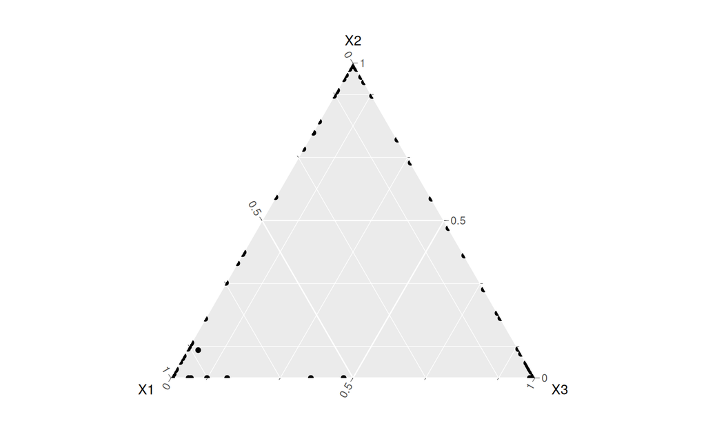

```r
# Load the library for plotting
# ternary plots:
library("ggtern")

# alpha is 3-dimensional:
alpha = c(1.5,2,1)

# Set the seed:
set.seed(1)

# Generate the data and plot them:

data = rdirichlet(n=500,alpha*0.01)
ggtern(data=data.frame(data),aes(X1,X2,X3))+
  geom_point()+
  scale_T_continuous(breaks=c(0,0.5,1), labels=c(0,0.5,1))+
  scale_L_continuous(breaks=c(0,0.5,1), labels=c(0,0.5,1))+
  scale_R_continuous(breaks=c(0,0.5,1), labels=c(0,0.5,1))
```

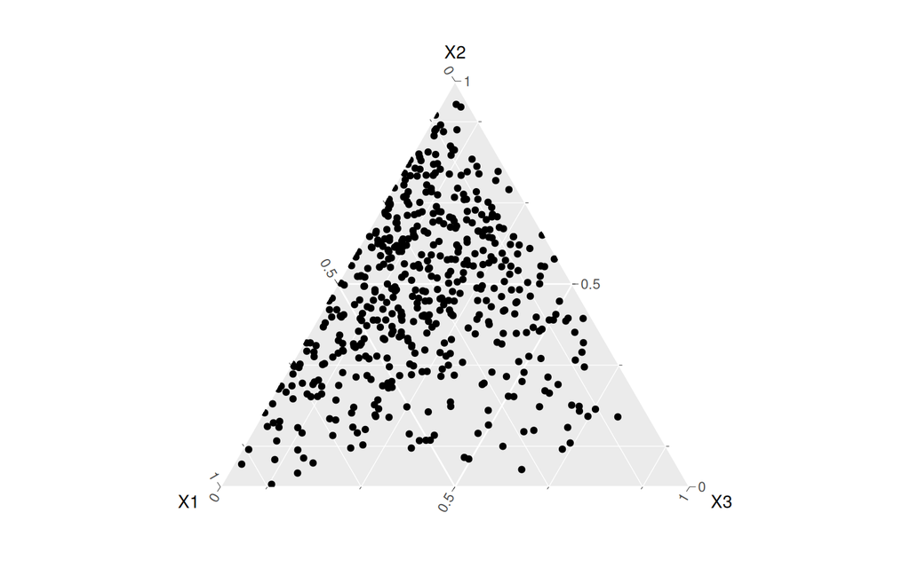

```r
data = rdirichlet(n=500,alpha*1)
ggtern(data=data.frame(data),aes(X1,X2,X3))+
  geom_point()+
  scale_T_continuous(breaks=c(0,0.5,1), labels=c(0,0.5,1))+
  scale_L_continuous(breaks=c(0,0.5,1), labels=c(0,0.5,1))+
  scale_R_continuous(breaks=c(0,0.5,1), labels=c(0,0.5,1))
```

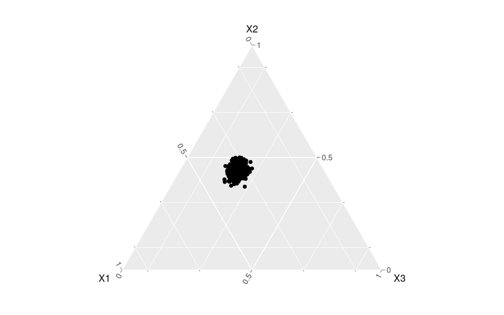

```r
data = rdirichlet(n=500,alpha*100)
ggtern(data=data.frame(data),aes(X1,X2,X3))+
  geom_point()+
  scale_T_continuous(breaks=c(0,0.5,1), labels=c(0,0.5,1))+
  scale_L_continuous(breaks=c(0,0.5,1), labels=c(0,0.5,1))+
  scale_R_continuous(breaks=c(0,0.5,1), labels=c(0,0.5,1))
```

Why does this matter for mixture models? Because the Dirichlet prior on the weights $p$ in effect tells the model whether we expect a *few large* clusters (small $\alpha_0$) or *many roughly-balanced* clusters (large $\alpha_0$). The default symmetric $\text{Dir}(1, \dots, 1)$ — uniform on the simplex — is a neutral choice that does not push the model either way.

Since each sample from a Dirichlet is itself a probability vector, we can use it to *generate* a categorical distribution and then draw realisations from that. The next plot shows three Dirichlet-generated 6-face dice and the empirical frequencies of $500$ rolls of each.

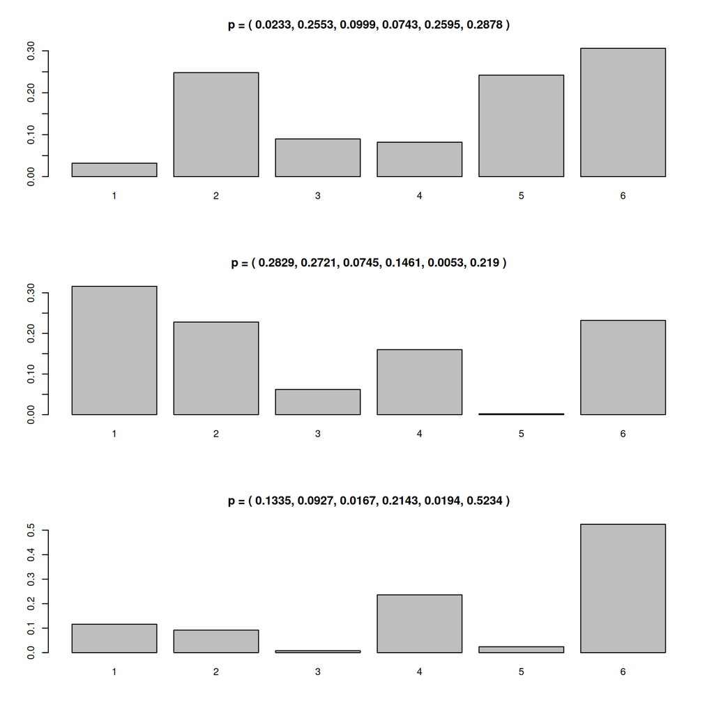

```r
# Set alpha:
alpha = rep(1,6)

# Plot the samples:
par(mfrow=c(3,1))
for(i in 1:3){
  p = rdirichlet(n=1, alpha)
  data = sample(1:6,500,replace=T,prob=p)
  barplot(table(data)/500,main=paste("p = (",toString(round(p,4)),")"))
}
```

## Remark: the Dirichlet–multinomial as the multivariate Beta–binomial

It is worth pausing on the broader role the Dirichlet plays in Bayesian statistics, beyond mixture models specifically.

In earlier lectures we used the **Beta–binomial** model to learn an unknown probability $\theta \in [0,1]$ from binary outcomes: a Beta prior on $\theta$, a binomial (or Bernoulli) likelihood for the data, and — by conjugacy — a Beta posterior. That model is the Bayesian way to learn the probability of a **two-outcome** event (success vs. failure, heads vs. tails).

The **Dirichlet–multinomial** model is the *exact same idea* generalised from two outcomes to $K$ outcomes. We have an event with $K$ disjoint possible outcomes and unknown probabilities $p = (p_1, \dots, p_K)$ summing to one. We put a $\text{Dirichlet}(\alpha_1, \dots, \alpha_K)$ prior on $p$, observe counts $(n_1, \dots, n_K)$ of each outcome from a multinomial likelihood, and the posterior is again Dirichlet:

$$p \sim \text{Dir}(\alpha_1, \dots, \alpha_K), \quad
(n_1, \dots, n_K) \mid p \sim \text{Multinomial}(n, p)
\;\Longrightarrow\;
p \mid n \sim \text{Dir}(\alpha_1 + n_1, \dots, \alpha_K + n_K).$$

When $K = 2$ this collapses exactly to Beta–binomial. So:

> **The Dirichlet distribution is the tool by means of which we learn, in Bayesian statistics, the probabilities of a finite set of disjoint events — i.e. the means by which we learn a discrete probability distribution.**

In a mixture model, “which component generated observation $i$” is precisely such a finite, disjoint event (it can be component $1$, or $2$, …, or $K$), and the mixing weights $p$ are the probabilities of those events. That is why the Dirichlet keeps reappearing in this lecture, and why every mixture below will have `p[1:H] ~ ddirich(a[])` as a building block. The Dirichlet is not a specialised “mixture-modelling tool” — it is the *generic* Bayesian tool for learning a categorical distribution, deployed here in one of its most useful applications.

# Finite mixture models: the full picture

We now formalise the mixture model and discuss the two subtle points that *every* implementation has to face: identifiability and label switching, and the two equivalent ways to write the likelihood in JAGS.

## The model

A **finite mixture distribution** with $K$ components is the convex combination

$$f(y) \;=\; \sum_{i=1}^{K} p_i\, f_i(y),
\qquad p_i \ge 0, \quad \sum_{i=1}^{K} p_i = 1.$$

The numbers $(p_1, \dots, p_K)$ are the **mixing weights** (or **mixing proportions**); the densities $f_i$ are the **components**.

There is a spectrum of how much structure we put on the components:

- **Known components, unknown weights.** Sometimes the $f_i$ are completely specified — e.g. the components are calibration profiles from a physical instrument — and the only unknowns are the proportions $p_i$.
- **Parametric components, unknown parameters.** Much more commonly, we assume each $f_i$ comes from a known parametric family with its own unknown parameter $\theta_i$: $f_i(y) = f(y \mid \theta_i)$, and the full model is

  $$f(y \mid p, \theta) \;=\; \sum_{i=1}^{K} p_i\, f(y \mid \theta_i).$$

  This is the case we work with in every example below. The unknowns are the weights and the component parameters jointly.

The flexibility of mixtures is striking. By choosing $K$ and the component family carefully one can approximate almost any continuous density on the real line; mixtures of Gaussians are dense in the space of continuous densities in a precise mathematical sense. This is why mixtures double as a *density estimation* tool even when the components have no real-world interpretation.

## Two ways to read a mixture

A finite mixture admits two equivalent readings, and which one you favour depends on what you want to do with the model.

The **density reading** writes the model as $f(y) = \sum_h p_h f(y \mid \theta_h)$ and treats the mixture as a flexible parametric density. This is the right reading for *density estimation* and for *model comparison*: the marginal likelihood $f(y \mid p, \theta)$ is what WAIC and PSIS-LOO ultimately need.

The **latent-allocation reading** introduces, for each observation, a hidden label $z_i \in \{1, \dots, K\}$ telling us which component generated it:

$$z_i \mid p \;\sim\; \mathcal{C}at(p),
\qquad
y_i \mid z_i, \theta \;\sim\; f(y_i \mid \theta_{z_i}).$$

Marginalising over $z_i$ gives back $f(y_i) = \sum_h p_h f(y_i \mid \theta_h)$, so the two readings produce the same data distribution. The latent reading is the right one for *clustering*: the posterior of $z_i$ is the soft cluster assignment for observation $i$.

## Identifiability and label switching

The mixture density $\sum_h p_h f(y \mid \theta_h)$ has a built-in symmetry: if we permute the index $h$ — say swap “component 1” and “component 2”, taking their weights and parameters with them — we get *exactly the same* density. This is called **non-identifiability up to label permutation**, and it has a practical consequence for MCMC.

When we run multiple chains, or even when a single chain wanders far enough, nothing in the likelihood penalises the sampler for relabelling the components half-way through. The trace plot of `mu[1]` may suddenly jump from one mode to another because the sampler now calls “component 1” what it previously called “component 3”. This phenomenon is **label switching**. It is *not* a bug; it is a feature of the model. The marginal density $f(y)$ and the in-sample information criteria are *invariant* to relabelling, so fitting and model comparison are unaffected. The only thing that *is* affected is the interpretation of “component 1”’s posterior summary, because “component 1” keeps changing identity.

The standard remedy — which we use throughout — is to *let the sampler run unconstrained* (so it can mix properly) and **relabel the posterior draws post-hoc** by some identifiable convention, typically sorting components by increasing mean. This is what the `relabel_by` helper below does.

## Two equivalent JAGS representations

When we translate the model to JAGS we have two natural ways to write the likelihood. They serve different purposes, and which one(s) we use depends on what we plan to do with the fit:

- **The latent-allocation representation** declares `z[i] ~ dcat(p[])` and `y[i] ~ ...` conditional on `z[i]`. It is transparent, matches the generative story, and gives us the cluster assignments for free as the posterior of `z[i]`. **Every** mixture model in this notebook uses this representation, because every analysis we run needs either the posterior of $z_i$ or, at a minimum, a way to sample $y_i$ component-by-component.
- **The marginalised mixture density.** Alongside the latent-allocation declaration, we can additionally compute and monitor

  $$\texttt{log\_lik}[i] \;=\; \log \sum_{h=1}^{K} p_h\, f(y_i \mid
  \theta_h),$$

  the per-observation log-density with the latent labels integrated out. We add this to the model **only when we plan to do model selection via WAIC or PSIS-LOO**, because that is when the pointwise log-likelihood is needed. Example 2 is the case study where we use it; Examples 1 and 3 do not need it and we leave it out, keeping those models slimmer.

The rule of thumb is therefore: latent allocation is always present; `log_lik[i]` is added only when model selection is on the menu.

# Example 1: a simulated bivariate Gaussian mixture

We begin with a deliberately simple example in two dimensions where **we know the truth**: we simulate the data ourselves from a two-component bivariate Gaussian mixture, then fit a model that is purposefully identical in structure to the true data-generating process. The point of an example like this is *sanity-checking*: if we cannot recover known parameters from simulated data under the matching model, we have no business trying to interpret a fit on real data.

We simulate the data from a mixture of two bivariate normals,

$$y\sim 0.6 \,\mathcal{N}_2
\left((4,4),
\begin{bmatrix} 0.5 & 0\\ 0 & 3\end{bmatrix}
\right)
+(1-0.6) \, \mathcal{N}_2
\left((1,2),
\begin{bmatrix} 2 & 0.4\\ 0.4 & 0.5\end{bmatrix}
\right).$$

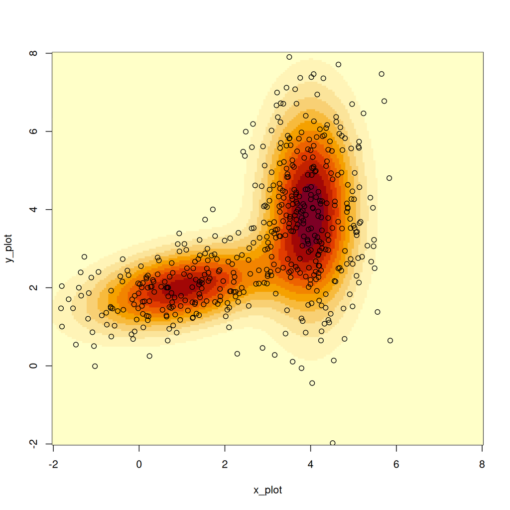

```r
library("mvtnorm")

mu1 = c(4,4)
mu2 = c(1,2)
sigma1 = matrix(data=c(0.5,0,0,3), nrow=2, ncol=2)
sigma2 = matrix(data=c(2,0.4,0.4,0.5), nrow=2, ncol=2)
w = 0.6
x_plot = seq(-2,8,length.out=200)
y_plot = seq(-2,8,length.out=200)

# Function to compute the p.d.f:
mixdens = function(x_plot, y_plot){
  return(dmvnorm(cbind(x_plot,y_plot),mean=mu1,sigma=sigma1)*w +
    dmvnorm(cbind(x_plot,y_plot),mean=mu2,sigma=sigma2)*(1-w))
}

# Function to simulate data:
rmixdens = function(n=1){
  idx_gaussian=sample(0:1, n, prob = c(w,1-w), replace = T)
  return((1-idx_gaussian)*rmvnorm(n,mean=mu1,sigma=sigma1)+
           idx_gaussian*rmvnorm(n,mean=mu2,sigma=sigma2))
}

# Generate and plot the sample:
image(x_plot, y_plot, outer(x_plot,y_plot,mixdens))
data = rmixdens(n=500)
points(data[,1],data[,2])
```

## The model

We now write down a Bayesian mixture model that mirrors the generative story. Because there are two components we can use a **Bernoulli** indicator $z_i \in \{0,1\}$ in place of the more general categorical, and a **Beta** prior on its success probability $w$ in place of the more general Dirichlet — the two formulations are completely equivalent for $K=2$:

$$Y_1,\dots,Y_n\overset{i.i.d.}\sim w \, \mathcal
N_2(\mu_1,\Sigma_1)+(1-w) \, \mathcal N_2(\mu_2,\Sigma_2) \\
w\sim Beta(1,1) \\
\mu_1,\mu_2\overset{i.i.d.}\sim \mathcal N(0,10) \\
\Sigma_1[1,1],
\Sigma_1[2,2],\Sigma_2[1,1],\Sigma_2[2,2]\overset{i.i.d.}\sim Gamma(1,1)
\\
\Sigma_1[1,2],\Sigma_2[1,2] \sim \mathcal N(0,10) \\
\Sigma_1[2,1]=\Sigma_1[1,2] \\
\Sigma_2[2,1]=\Sigma_2[1,2]$$
where $\Sigma_j[i,k]$ is the $(i,k)$ entry of the $j$-th component’s covariance matrix. Two priors deserve a comment. The off-diagonal elements of the covariance can be positive or negative, so a (vague) normal prior on $\mathbb R$ is appropriate. The diagonal elements must be positive, and a Gamma prior puts mass only on the positive reals — perfect. Note that this component-wise specification does *not* guarantee the resulting matrix is positive-definite, only that its diagonal is positive; in the exercise below we will see a cleaner alternative (the Wishart prior) that automatically gives us positive-definite covariances.

We translate this into JAGS as follows. JAGS works with **precisions** (the inverse of variance, or the inverse of the covariance matrix in the multivariate case): the symbol `sigma[k,,]` in the code below is actually the *precision matrix* of component $k$, despite the name. The Bernoulli latent `z[i]` decides which of the two components observation $i$ comes from.

```r
model_string = textConnection(
"model{

  # Likelihood
  for(i in 1:N){
    z[i] ~ dbern(w)
    y[i,1:2] ~ dmnorm(mu[z[i]+1,1:2],sigma[z[i]+1,1:2,1:2])

  }

  # Prior
  mu[1,1] ~ dnorm(0,0.1)
  mu[1,2] ~ dnorm(0,0.1)
  mu[2,1] ~ dnorm(0,0.1)
  mu[2,2] ~ dnorm(0,0.1)
  w ~ dbeta(1,1)

  sigma[1,1,1] ~ dgamma(1,1)
  sigma[1,1,2] ~ dnorm(0,0.1)
  sigma[1,2,1] = sigma[1,1,2]
  sigma[1,2,2] ~ dgamma(1,1)

  sigma[2,1,1] ~ dgamma(1,1)
  sigma[2,1,2] ~ dnorm(0,0.1)
  sigma[2,2,1] = sigma[2,1,2]
  sigma[2,2,2] ~ dgamma(1,1)

}")
```

We compile and run the sampler with the standard `jags.model` / `update` / `coda.samples` routine. We monitor all parameters *and* the cluster labels `z`, because looking at the posterior of the labels will let us produce the soft-clustering plot at the end of this section.

```r
# Sampling setup:
dataList = list(y=data,N=500)
variable.names = c("mu","sigma","w","z")

burn   = 500
n.iter = 1500
thin   = 1

model = jags.model(model_string, data = dataList)
update(model, n.iter = burn)
output = coda.samples(model, variable.names = variable.names,
                      n.iter = n.iter, thin = thin)
```

Below we plot the trace and posterior density of the 13 continuous parameters (the means, the precision matrices, and the weight $w$). We skip the cluster labels `z`, which only take the values $0$ or $1$ and are better summarised graphically.

When you look at the trace plots, note how each chain explores a *single* mode because the simulated components are well separated and the initial values land the chain near the right component — label switching is a real risk, but it does not bite us here.

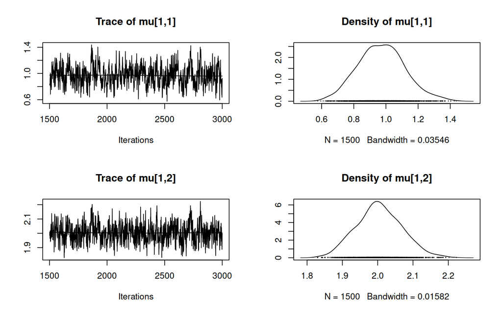

```r
# Trace plot and densities:
plot(output[,c("mu[1,1]","mu[1,2]")])
```

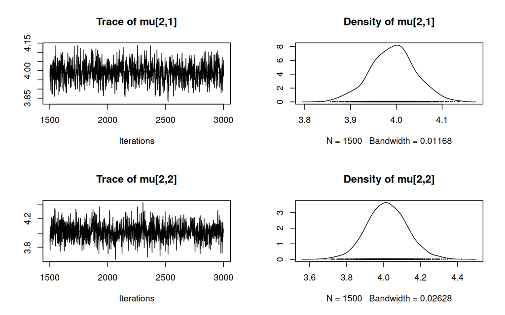

```r
plot(output[,c("mu[2,1]","mu[2,2]")])
```

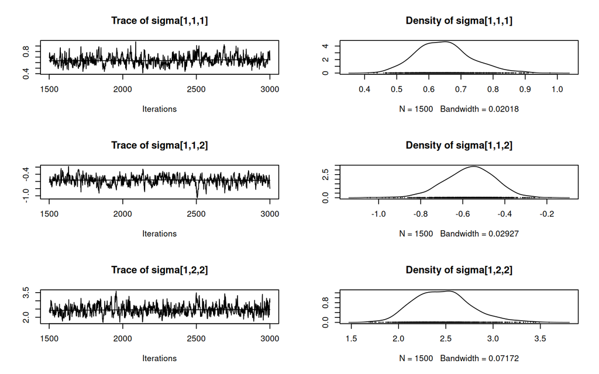

```r
plot(output[,c("sigma[1,1,1]","sigma[1,1,2]","sigma[1,2,2]")])
```

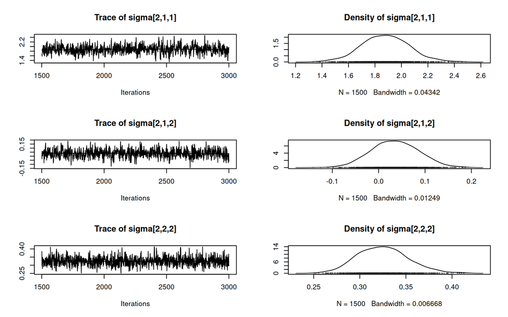

```r
plot(output[,c("sigma[2,1,1]","sigma[2,1,2]","sigma[2,2,2]")])
```

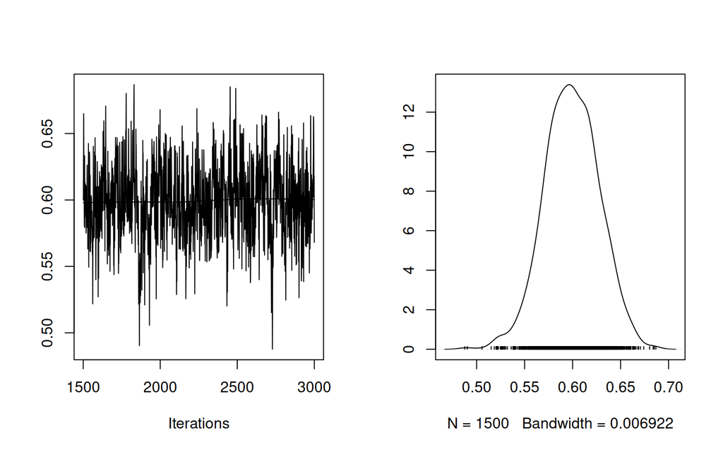

```r
plot(output[,"w"])
```

## From samples to a density estimate

The posterior is a distribution over the mixture parameters, but for many practical purposes — e.g. plotting, prediction, comparing to data — what we actually want is a single estimate of the density $f(y)$. The Bayesian answer is the **posterior predictive density**:

$$\hat f(y) \;=\; \mathbb E_{p,\theta \mid \text{data}}\bigl[\, f(y \mid
p, \theta)\,\bigr]
\;\approx\; \frac{1}{T}\sum_{t=1}^{T} f\bigl(y \mid p^{(t)},
\theta^{(t)}\bigr).$$

In words: at each MCMC iteration $t$ we have a complete mixture density,

$$w^{(t)}\,\mathcal N_2\!\left(\mu_1^{(t)},\Sigma_1^{(t)}\right) + \bigl(1
- w^{(t)}\bigr)\,\mathcal N_2\!\left(\mu_2^{(t)},\Sigma_2^{(t)}\right),$$

evaluate it on a grid, and *average* the resulting density surface across iterations. The average automatically integrates parameter uncertainty into the density estimate.

Let us first look at what we get from a *single* iteration. We pick iteration $745$ arbitrarily and visualise the corresponding density.

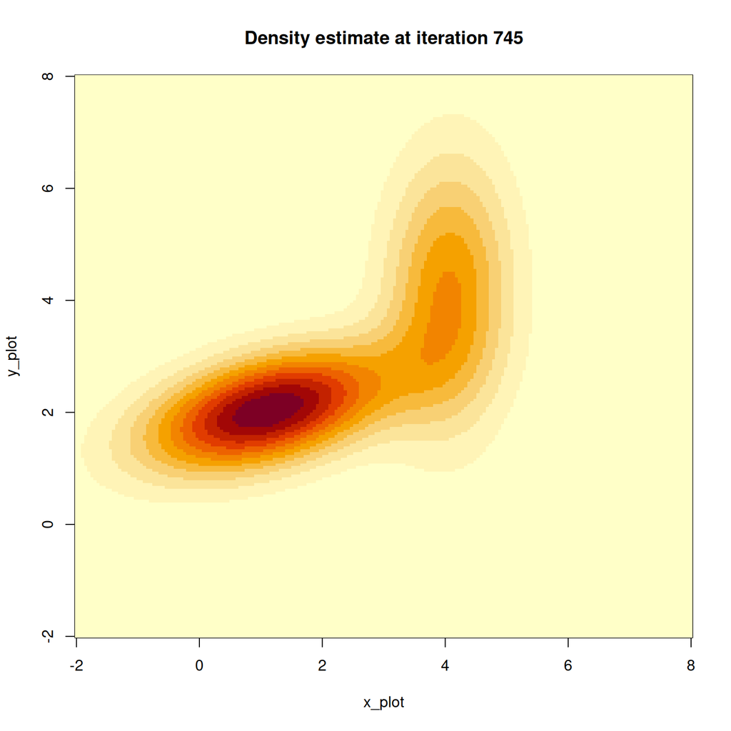

```r
# Function for evaluating the mixture p.d.f:
sampledmixdens = function(x_plot,y_plot,iteration,output_mcmc){

  output = as.matrix(output_mcmc)
  precmat1 = matrix(c(output[iteration,"sigma[1,1,1]"],
                      output[iteration,"sigma[1,1,2]"],
                      output[iteration,"sigma[1,2,1]"],
                      output[iteration,"sigma[1,2,2]"]), nrow=2, ncol=2)
  sigma1 = solve(precmat1)
  precmat2 = matrix(c(output[iteration,"sigma[2,1,1]"],
                    output[iteration,"sigma[2,1,2]"],
                    output[iteration,"sigma[2,2,1]"],
                    output[iteration,"sigma[2,2,2]"]), nrow=2, ncol=2)
  sigma2 = solve(precmat2)
  mu1 = c(output[iteration,"mu[1,1]"], output[iteration,"mu[1,2]"])
  mu2 = c(output[iteration,"mu[2,1]"], output[iteration,"mu[2,2]"])
  w = output[iteration,"w"]

  return(dmvnorm(cbind(x_plot,y_plot),mean=mu1,sigma=sigma1)*w +
  dmvnorm(cbind(x_plot,y_plot),mean=mu2,sigma=sigma2)*(1-w))
}

# Example inputs:
iteration = 745
x_plot = seq(-2,8,length.out=200)
y_plot = seq(-2,8,length.out=200)

# Plot the density:
image(x_plot,y_plot,outer(x_plot,y_plot,sampledmixdens,iteration,output),
      main=paste("Density estimate at iteration", iteration))
```

That single-iteration density is noisy: it depends entirely on the parameter values that happened to be drawn at iteration $745$, and a neighbouring iteration would give a noticeably different surface. The fix is to average over all iterations:

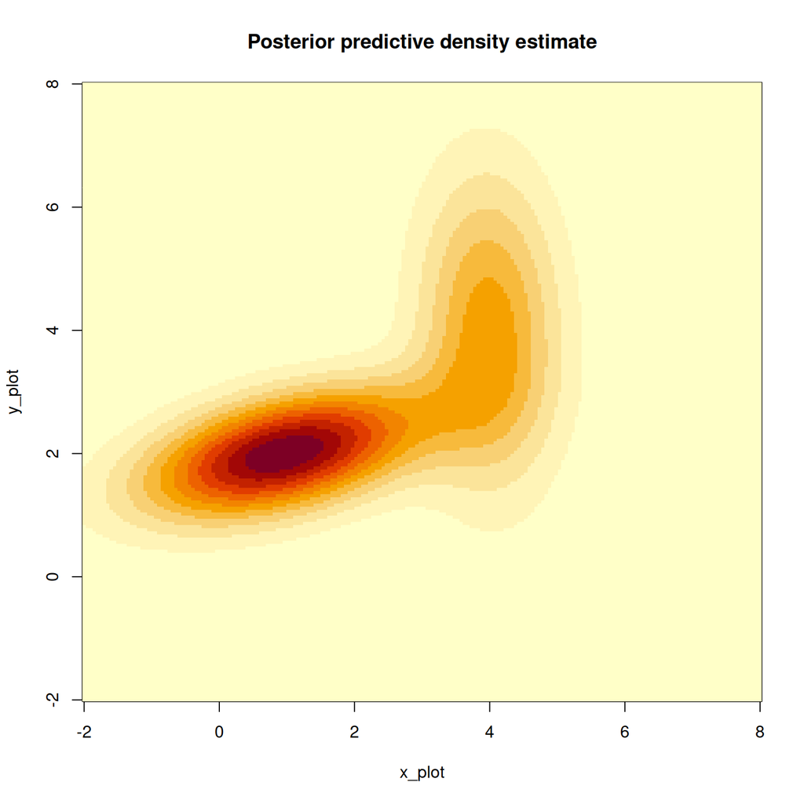

```r
# Setup:
nit = 1500
meandensity = matrix(0,200,200)

# Sum up the densities for each iteration:
for(iteration in 1:nit){
  meandensity = meandensity + outer(x_plot,y_plot,sampledmixdens,iteration,output)
}

# Sample mean:
meandensity = meandensity / nit

# Plot the density:
image(x_plot, y_plot, meandensity, main="Posterior predictive density estimate")
```

## Soft cluster assignments

Now we look at the cluster labels themselves, the `z[i]`‘s. Recall that in `model_string` we declared one latent label per observation, so there are $N$ such variables, each taking values in $\{0, 1\}$. At each MCMC iteration we get a *complete labelling* of every observation: one snapshot of “who belongs to which cluster”. The collection of those snapshots is the posterior of the clustering — and it tells us much more than $K$-means’ single hard assignment.

For a single iteration we can show the data points coloured by their current assignment. Crucially, points near the boundary between the two components will get assigned differently at different iterations: that variability *is* the posterior uncertainty about the cluster identity of those points.

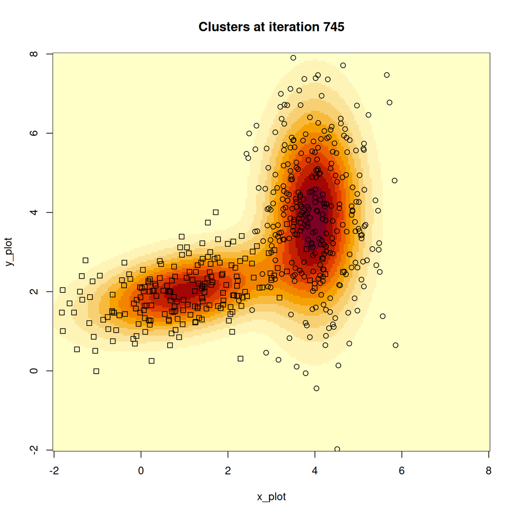

```r
# Settings:
output_mat = as.matrix(output)
iteration = 745

# Select the z[i]'s and plot their samples:
image(x_plot,y_plot,outer(x_plot,y_plot,mixdens),main=paste("Clusters at iteration", iteration))
points(data[,1],data[,2], pch=output_mat[iteration,14:513])
```

## Exercise 1: a Wishart prior for the covariance

The prior we used above puts independent priors on each entry of the covariance matrix. This is convenient but has two problems: it ignores the dependence between entries (variances and covariances are not free to vary independently), and worse, it does *not* enforce positive-definiteness — the only thing that makes a covariance matrix a valid covariance matrix.

The proper multivariate prior for a precision matrix is the **Wishart distribution**, denoted $W \sim \text{Wish}(V,m)$, where $V$ is a positive $p \times p$ scale matrix and $m \ge p$ is the degrees-of-freedom parameter. Its density is

$$f_W(w) =
\frac{|w|^{(m-p-1)/2}\exp[-trace(V^{-1}w/2)]}{2^{mp/2}|V|^{m/2}\Gamma_p(m/2)}.$$

When $p = 1$ the Wishart reduces to a Gamma, so the Wishart is the multivariate generalisation of the Gamma — exactly the role of the Dirichlet relative to the Beta. The decisive advantage of using a Wishart prior on the precision matrix is that **every draw from a Wishart is positive-definite by construction**, so the model can never wander into invalid covariance matrices.

We rewrite the JAGS code with `sigma[k, , ]` for the $k$-th component’s precision matrix; the first index labels the component, and the second and third index the rows and columns. The scale matrix $V = I$ and degrees of freedom $m = 3$ together give a weakly-informative Wishart prior. Execute the code and compare the cluster reconstruction to the one obtained above.

```r
model_string = textConnection(
"model{

  # Likelihood
  for(i in 1:N){
    z[i] ~ dbern(w)
    y[i,1:2] ~ dmnorm(mu[z[i]+1,1:2],sigma[z[i]+1,1:2,1:2])
  }

  # Prior
  mu[1,1] ~ dnorm(0,0.1)
  mu[1,2] ~ dnorm(0,0.1)
  mu[2,1] ~ dnorm(0,0.1)
  mu[2,2] ~ dnorm(0,0.1)
  w ~ dbeta(1,1)

  sigma[1,1:2,1:2] ~ dwish(R,3)
  sigma[2,1:2,1:2] ~ dwish(R,3)

  R[1,1] = 1
  R[2,2] = 1
  R[1,2] = 0
  R[2,1] = 0

}")
```

# Example 2: Gaussian mixture — the Galaxy dataset

We now move from a controlled simulation to a real dataset, and from a known number of components to the central, hard question of mixture modelling: **how many components does the data actually support?** The galaxy dataset is the textbook setting in which to answer this question.

The `galaxy` dataset records $82$ observations of the radial velocities (in units of $1000$ km/s) of distant galaxies diverging from six well-separated conic sections of the Corona Borealis. Velocity is the closest thing to distance that we can measure for very far away objects, and a multimodal velocity distribution is evidence of *superclusters* — groups of galaxies that sit at similar distances and move together. The question is: how many such superclusters are there in this slice of the universe?

This dataset has become a benchmark in the statistical literature precisely because the answer is genuinely unclear. Different methods give different answers in the range $3$–$7$, and the true number depends on what counts as a “meaningful” peak.

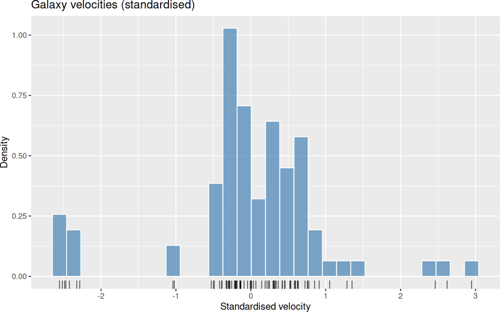

```r
data_gal = as.numeric(galaxies)
data_gal = (data_gal - mean(data_gal)) / sd(data_gal)   # standardise

ggplot(data.frame(y = data_gal), aes(y)) +
  geom_histogram(aes(y = after_stat(density)), bins = 30,
                 fill = "steelblue", colour = "white", alpha = 0.7) +
  geom_rug(sides = "b", alpha = 0.6) +
  labs(title = "Galaxy velocities (standardised)",
       x = "Standardised velocity", y = "Density")
```

The histogram shows at least four groups, with two of them in the central portion of the density carrying particularly high mass — these are exactly the peaks whose interpretation is ambiguous. The raw values are tens of thousands of km/s, so for numerical convenience we **standardise** the data to zero mean and unit variance. Standardisation has no effect on the inferential content of the analysis, but it makes prior elicitation much easier — once the data are on a $O(1)$ scale, weakly-informative priors with familiar scales (e.g. $\mathcal N(0, 100)$ on means, $\text{Unif}(0.05, 5)$ on standard deviations) make sense automatically.

## The model

We consider a univariate Gaussian mixture with $H$ components, written in the latent-allocation form for transparency:

$$Y_i\mid Z_i=z_i\sim\mathcal N(\mu_{z_i}, \sigma^2_{z_i}), \\
Z_1,\dots,Z_n\mid p \overset{i.i.d.}\sim \mathcal{C}at(p), \\
p\sim Dirichlet(1,\dots,1), \\
\mu_1,\dots,\mu_H\overset{i.i.d.}\sim \mathcal N(0,0.01), \\
\frac1{\sigma_1^2},\dots,\frac1{\sigma_H^2}\overset{i.i.d.}\sim\mathcal{G}a(0.01,0.01).$$

Here $\mathcal{C}at(p)$ denotes the [categorical distribution](https://en.wikipedia.org/wiki/Categorical_distribution), a single-draw special case of the multinomial. $H$ — the number of normal components — is *fixed* in any given fit; the model-selection question below will fit the model for several values of $H$ and compare.

A practical comment on the priors. The data are standardised, so we put the prior directly on the component **standard deviation** as $\text{Unif}(0.05, 5)$ rather than on the precision as a vague $\text{Gamma}(0.01, 0.01)$. The latter is a popular weakly-informative choice in textbooks, but for mixtures with many components some of the components are nearly empty during MCMC, and a $\text{Gamma}(0.01, 0.01)$ prior on the precision has *infinite density* at zero variance, which lets an empty component drift towards a degenerate spike of zero variance. The sampler then explodes (in our case with the error *“Invalid parent values for sigma”*). A bounded uniform on the standard deviation cleanly avoids this pathology.

Inside the model we also compute and monitor the **observed-data pointwise log-likelihood** with the latent labels marginalised out,

$$\log p(y_i\mid p,\mu,\sigma) \;=\; \log \sum_{h=1}^{H} p_h\,\mathcal
N\!\bigl(y_i\mid\mu_h,\sigma_h^2\bigr).$$

This is the quantity the information criteria require, as we will discuss in the “*Model selection*” section below. Computing the sum naïvely is numerically dangerous: if one component is far from $y_i$, its individual density can underflow to $0$, the sum becomes the other component’s density, and rounding can send the whole expression to $-\infty$. The standard fix is the **log-sum-exp** trick. Form the per-component log contributions $\ell_{ih} = \log p_h + \log\mathcal N(y_i\mid\mu_h,\sigma_h^2)$, let $m_i = \max_h \ell_{ih}$, and write

$$\log \sum_h e^{\ell_{ih}} \;=\; m_i + \log \sum_h e^{\ell_{ih} - m_i}.$$

The exponentials inside the sum are all in $(0,1]$ — the largest is exactly $1$ — so no underflow can occur. We implement this directly in JAGS using the built-in `logdensity.norm` (so the component log-densities are exact) and the scalar `exp`, `log` and `max` functions.

The components are exchangeable, so the chains will inevitably exhibit **label switching**. The marginal log-likelihood and the information criteria are invariant to relabelling, so this does not affect either density estimation or model selection. For *interpretable* component summaries we will relabel the posterior draws after sampling, by increasing component mean.

```r
model_gauss_mix <- "
model {

  # Likelihood with latent allocation + marginal log-likelihood for WAIC/LOO.
  for (i in 1:N) {
    z[i] ~ dcat(p[])
    y[i] ~ dnorm(mu[z[i]], tau[z[i]])

    # Per-component log mixture contribution, log(p_h) + log N(y_i | mu_h, tau_h).
    # We use logdensity.norm (exact, no manual exp/sqrt) and combine the H
    # components with a numerically safe log-sum-exp. exp() is a *scalar*
    # function in JAGS, so the exponential is taken element-by-element in the
    # loop and only then summed.
    for (h in 1:H) {
      lcomp[i,h] <- log(p[h]) + logdensity.norm(y[i], mu[h], tau[h])
    }
    mx[i] <- max(lcomp[i,])
    for (h in 1:H) {
      e[i,h] <- exp(lcomp[i,h] - mx[i])
    }
    log_lik[i] <- mx[i] + log(sum(e[i,]))
  }

  # Priors on the component parameters.
  # The data are standardised, so we put a weakly-informative prior directly on
  # the component standard deviations (avoids the spike-at-zero pathology of a
  # vague Gamma(0.01,0.01) on the precision, which is what produced
  # 'Invalid parent values for sigma[.]').
  for (h in 1:H) {
    mu[h]    ~ dnorm(0, 0.01)
    sigma[h] ~ dunif(0.05, 5)          # standardised data => sd in a sane range
    tau[h]   <- 1 / (sigma[h] * sigma[h])
  }

  # Dirichlet prior on the weights
  p[1:H] ~ ddirich(a[])
}
"
```

The helper below applies the relabelling: at each MCMC iteration we sort the component indices by some key (typically the mean) and reorder the means, standard deviations and weights together so they remain aligned. This is a pure post-processing step — the fit itself is untouched.

```r
# Post-hoc relabelling of mixture draws by increasing component "key" (e.g. the
# mean). Returns the posterior draws with columns reordered per iteration so
# that key[1] <= key[2] <= ... This tames label switching for reporting without
# touching the (permutation-invariant) fit.
relabel_by <- function(samp_mat, H, key_cols, move_groups) {
  out <- samp_mat
  for (i in seq_len(nrow(samp_mat))) {
    o <- order(samp_mat[i, key_cols])
    for (g in move_groups) out[i, g] <- samp_mat[i, g[o]]
  }
  out
}
```

## Fitting one model ($H = 6$ components)

Before tackling the model-selection question, we fit a single model with $H = 6$ components to get a feel for what the posterior looks like. We picked $6$ rather than $4$ because the histogram has two central bumps that a $4$-component model tends to collapse into a single wider Gaussian — six components give the model enough flexibility to fit the central region properly.

A subtle but important point: a Bayesian mixture sampler is *very* sensitive to **initial values**. If two chains start with identical or near-identical component means, the sampler has trouble splitting them; if one chain places a component in a region with no data, its variance can drift to extreme values and crash JAGS. We use a small `gauss_inits` helper that spreads the initial component means across the data quantiles and starts the standard deviations at modest, finite values — a textbook trick to keep the MCMC well-behaved.

```r
# Initial values for a Gaussian mixture: means at evenly spaced data quantiles,
# unit-ish sds, uniform weights. Returns a function (one draw per chain).
gauss_inits <- function(y, H) {
  function() {
    qs <- as.numeric(quantile(y, probs = seq(0.1, 0.9, length.out = H)))
    list(mu    = qs + rnorm(H, 0, 0.05),
         sigma = runif(H, 0.4, 0.9),
         p     = rep(1 / H, H))
  }
}
```

For this single illustrative fit we only need the component parameters; the `log_lik[i]` quantity computed by `model_gauss_mix` is used by the model- selection sweep below, so we postpone monitoring it until then.

```r
H <- 6
dataList_gal <- list(y = data_gal, N = length(data_gal),
                     H = H, a = rep(1, H))

samples_gal6 <- fit_mixture(
  model_gauss_mix, dataList_gal,
  variable.names = c("mu", "sigma", "p"),
  burn = 5000, n.iter = 10000, thin = 5, n.chains = 3, n.adapt = 2000,
  inits = gauss_inits(data_gal, H)
)
```

### Diagnostics

The raw component traces will display **label switching**: components swap the regions they explore, because the likelihood is invariant to relabelling. The marginal density and the information criteria are unaffected, but the component-specific posterior summary is meaningless until we relabel. The code chunk below pulls the draws into a matrix, relabels each row by increasing component mean using `relabel_by`, and produces an interpretable summary table of means, standard deviations and weights, together with $95\%$ credible intervals.

For convergence we look at two things. The **effective sample size** tells us how many *independent* draws our (correlated) MCMC sample is worth — ideally in the hundreds or more. The **Gelman–Rubin $\hat R$** compares the within-chain to the between-chain variance; values close to $1$ are good and values above $1.1$ are warning signs. In a mixture the per-component $\hat R$ can look inflated when label switching is happening — that is *expected*, not pathological.

```r
mat_gal6  <- as.matrix(samples_gal6)
mu_cols   <- paste0("mu[",    1:H, "]")
sigma_cols<- paste0("sigma[", 1:H, "]")
p_cols    <- paste0("p[",     1:H, "]")

# Relabel draws by increasing mean (keeps mu, sigma, p aligned per component)
mat_gal6_rl <- relabel_by(mat_gal6, H, key_cols = mu_cols,
                          move_groups = list(mu_cols, sigma_cols, p_cols))

# Posterior summary of the relabelled component parameters
round(t(apply(mat_gal6_rl[, c(mu_cols, sigma_cols, p_cols)], 2,
              function(x) c(mean = mean(x), sd = sd(x),
                            `2.5%` = quantile(x, .025),
                            `97.5%` = quantile(x, .975)))), 3)
```

```
##            mean    sd 2.5%.2.5% 97.5%.97.5%
## mu[1]    -5.824 5.305   -20.315      -2.346
## mu[2]    -1.846 2.037    -7.758       0.088
## mu[3]    -0.370 0.940    -2.473       0.616
## mu[4]     0.461 0.876    -0.322       2.736
## mu[5]     1.734 2.123     0.095       7.931
## mu[6]     5.845 5.668     0.473      21.031
## sigma[1]  1.374 1.622     0.070       4.800
## sigma[2]  0.889 1.321     0.069       4.576
## sigma[3]  0.724 1.021     0.077       4.137
## sigma[4]  0.889 0.972     0.104       3.923
## sigma[5]  1.416 1.232     0.177       4.545
## sigma[6]  2.102 1.393     0.192       4.807
## p[1]      0.051 0.045     0.001       0.145
## p[2]      0.146 0.172     0.002       0.743
## p[3]      0.280 0.236     0.004       0.818
## p[4]      0.302 0.243     0.006       0.814
## p[5]      0.174 0.208     0.002       0.729
## p[6]      0.046 0.076     0.001       0.254
```

```r
# Convergence diagnostics on the (permutation-invariant) log-likelihood scale
core_pars <- c(mu_cols, sigma_cols, p_cols)
effectiveSize(samples_gal6[, core_pars])
```

```
##      mu[1]      mu[2]      mu[3]      mu[4]      mu[5]      mu[6]   sigma[1]
##  317.36608 4288.76401 1913.36922 2400.46825 3629.06987 3140.38435   46.08985
##   sigma[2]   sigma[3]   sigma[4]   sigma[5]   sigma[6]       p[1]       p[2]
##  109.83333  106.66606   84.32562  227.66623  117.20679  142.69970   79.28832
##       p[3]       p[4]       p[5]       p[6]
##   85.93220  108.53692   87.13895   70.64191
```

```r
gr_table(samples_gal6[, core_pars])
```

Gelman–Rubin R-hat (values < 1.1 indicate convergence)

|  | Point est. | Upper C.I. |
| --- | --- | --- |
| mu[1] | 1.0533 | 1.1543 |
| mu[2] | 1.0132 | 1.0164 |
| mu[3] | 1.0144 | 1.0507 |
| mu[4] | 1.0159 | 1.0346 |
| mu[5] | 1.0018 | 1.0026 |
| mu[6] | 1.0048 | 1.0140 |
| sigma[1] | 1.0735 | 1.2123 |
| sigma[2] | 1.0303 | 1.0920 |
| sigma[3] | 1.0157 | 1.0528 |
| sigma[4] | 1.0464 | 1.1499 |
| sigma[5] | 1.0004 | 1.0021 |
| sigma[6] | 1.0015 | 1.0044 |
| p[1] | 1.2453 | 1.8326 |
| p[2] | 1.1628 | 1.5011 |
| p[3] | 1.1056 | 1.2934 |
| p[4] | 1.0578 | 1.1268 |
| p[5] | 1.0480 | 1.1237 |
| p[6] | 1.0979 | 1.2787 |

The trace plots below illustrate label switching directly: components hop between regions of the parameter space as the sampler relabels them. The *joint* sampling is fine — only the per-component “name” keeps changing.

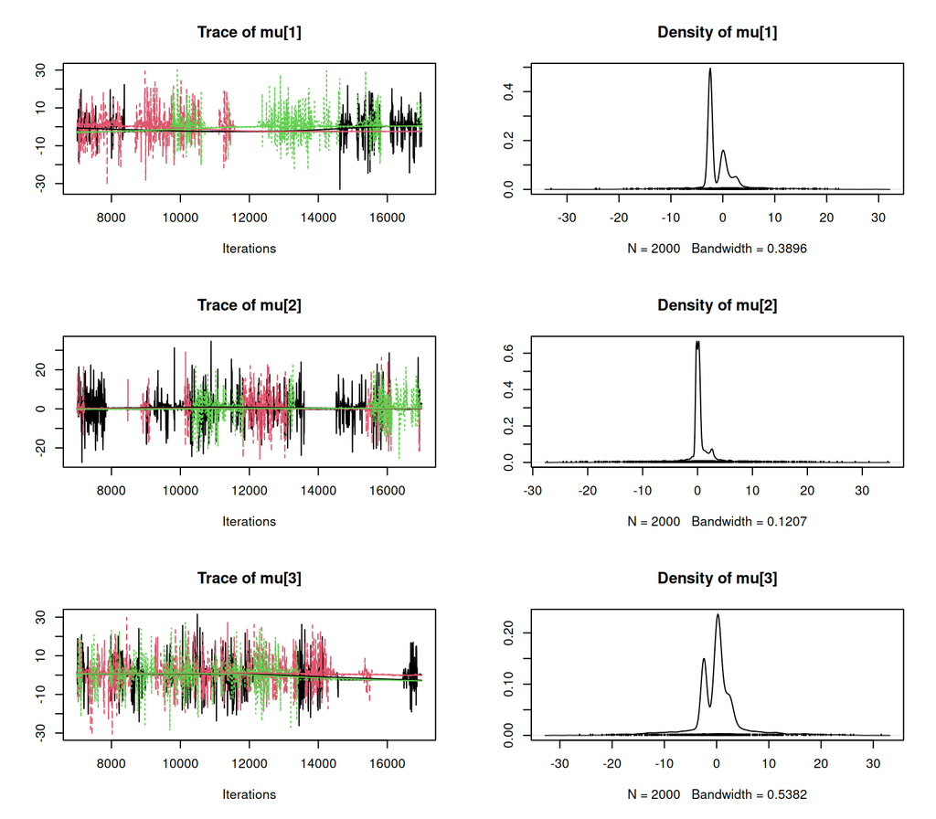

```r
plot(samples_gal6[, paste0("mu[",    1:3, "]")])
```

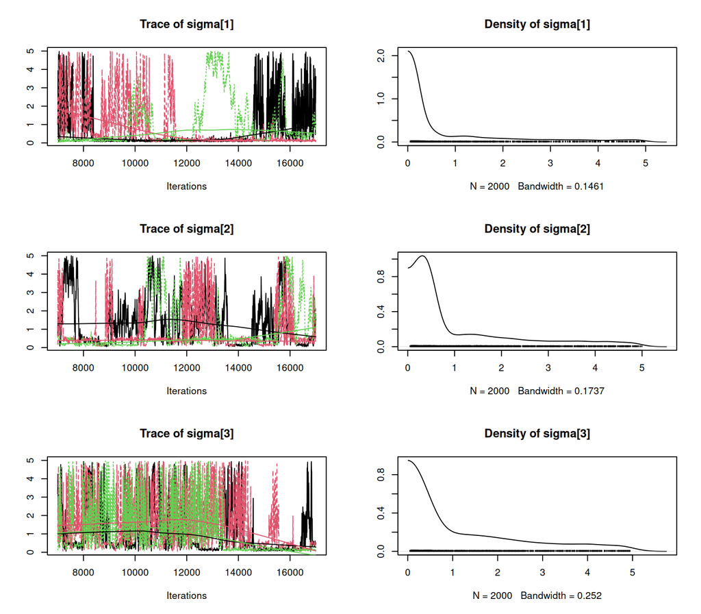

```r
plot(samples_gal6[, paste0("sigma[", 1:3, "]")])
```

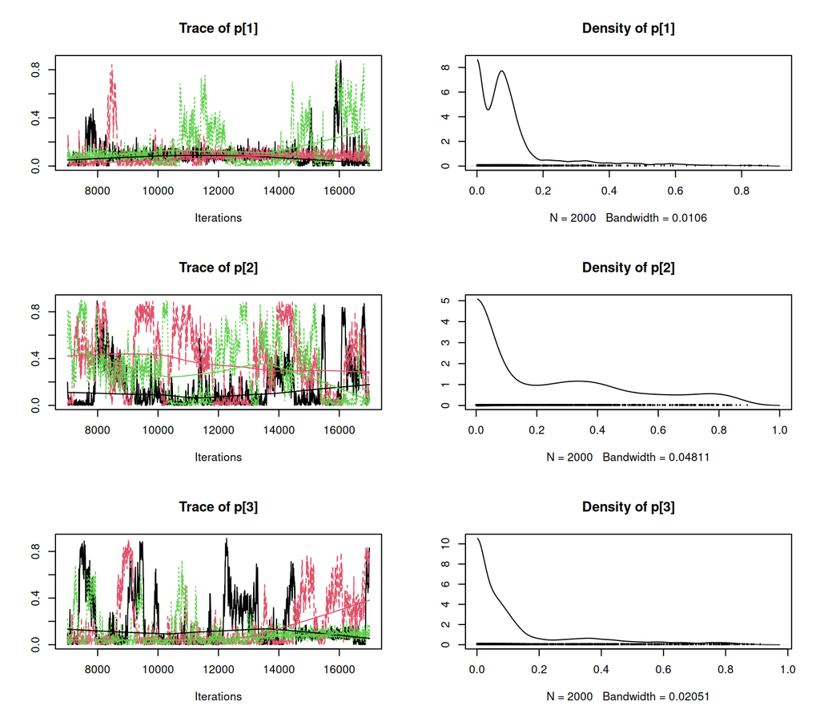

```r
plot(samples_gal6[, paste0("p[",     1:3, "]")])
```

### Posterior predictive density

Once we have the posterior draws, the **posterior predictive density** is the single best summary of “what the model thinks the data look like”. As in Example 1 we compute it by averaging the per-iteration mixture density over draws — and we additionally compute a *pointwise* $95\%$ credible band by taking the $2.5\%$ and $97.5\%$ quantiles of the density values at each point $x$. The band tells us where the model is confident about the density and where it is not.

We package the computation as a small reusable evaluator `ppd_gauss` so the same pattern can be applied to any matrix of posterior draws from a Gaussian mixture (and we will reuse it below when selecting $H$).

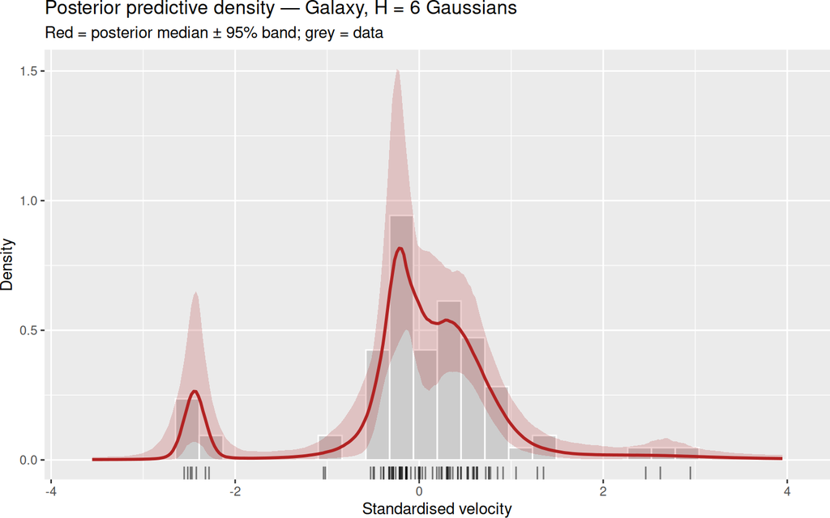

```r
# Posterior predictive of a Gaussian mixture from a matrix of draws.
ppd_gauss <- function(samp_mat, H, x_grid, n_draws = 1000) {
  mu_cols    <- paste0("mu[",    1:H, "]")
  sigma_cols <- paste0("sigma[", 1:H, "]")
  p_cols     <- paste0("p[",     1:H, "]")
  idx <- sample(nrow(samp_mat), min(n_draws, nrow(samp_mat)))
  dens <- sapply(idx, function(j) {
    mu_j <- samp_mat[j, mu_cols]; s_j <- samp_mat[j, sigma_cols]
    p_j  <- samp_mat[j, p_cols]
    rowSums(sapply(1:H, function(h) p_j[h] * dnorm(x_grid, mu_j[h], s_j[h])))
  })
  data.frame(x   = x_grid,
             med = apply(dens, 1, median),
             lo  = apply(dens, 1, quantile, 0.025),
             hi  = apply(dens, 1, quantile, 0.975))
}

mat_gal6 <- as.matrix(samples_gal6)
x_grid   <- seq(min(data_gal) - 1, max(data_gal) + 1, length.out = 300)
ppd6     <- ppd_gauss(mat_gal6, H, x_grid)

ggplot() +
  geom_histogram(data = data.frame(y = data_gal),
                 aes(y, after_stat(density)), bins = 30,
                 fill = "grey80", colour = "white") +
  geom_ribbon(data = ppd6, aes(x, ymin = lo, ymax = hi),
              fill = "firebrick", alpha = 0.2) +
  geom_line(data = ppd6, aes(x, med), colour = "firebrick", linewidth = 1) +
  geom_rug(data = data.frame(y = data_gal), aes(y), sides = "b", alpha = 0.5) +
  labs(title    = "Posterior predictive density — Galaxy, H = 6 Gaussians",
       subtitle = "Red = posterior median ± 95% band; grey = data",
       x = "Standardised velocity", y = "Density")
```

## Model selection: how many components?

So far we have *assumed* $H = 6$. The harder, more interesting question is which value of $H$ best describes the data. We will answer it by fitting the model for a range of component counts $H \in \{2, \dots, 8\}$, and ranking the fits with two modern information criteria: **WAIC** (Widely Applicable Information Criterion) and **PSIS-LOO** (Pareto-Smoothed Importance Sampling estimate of Leave-One-Out cross-validation).

A few words on what these criteria actually do.

The idealised quantity we want to estimate is the **expected log predictive density** on a *new* observation, $\text{elpd} = \mathbb{E}_{\tilde y \sim f^{\text{true}}}[\log p(\tilde y \mid \text{data})]$, which measures how well a model would predict future data drawn from the same data-generating process. Higher elpd means better out-of-sample predictive performance.

The in-sample log likelihood $\sum_i \log p(y_i \mid \text{data})$ over-estimates elpd because each $y_i$ contributes to both fitting the model and evaluating its fit. The criteria are two principled ways to **correct for this overfitting**:

- **WAIC** subtracts the variance of the log-predictive density across posterior draws, computed pointwise, as an “effective parameter count” penalty.
- **PSIS-LOO** approximates leave-one-out cross-validation efficiently by reweighting the existing posterior draws.

In both cases what is reported is twice the negative elpd estimate, so **lower values mean a better expected predictive performance**, and both come with a standard error so we can tell when two models are really distinguishable. A difference of more than about $2$ standard errors (so roughly $4$ on the WAIC scale) is usually called “meaningful” evidence; smaller differences are statistical ties.

### What `loo` needs from us: the pointwise log-likelihood

We did not work through the `loo` package in its own lecture, so it is worth being explicit about *how* WAIC and PSIS-LOO connect to our JAGS code. Both criteria compute their bias correction **one observation at a time**: they need, for each MCMC draw $t$ and each observation $i$ separately, the value of the **pointwise log-likelihood**

$$\ell_{ti} \;=\; \log p\bigl(y_i \mid \theta^{(t)}\bigr),$$

and they expect to receive an $S \times n$ matrix `log_lik[t, i]` containing all of these numbers. This is the matrix shape that the helper `extract_ll` reshapes the monitored output into.

For a simple one-distribution model this is one extra line per observation: write `log_lik[i] <- logdensity.norm(y[i], mu, tau)` (or `logdensity.beta`, `logdensity.gamma`, …) next to the sampling statement and monitor `log_lik`. For a *mixture* the per-observation density is itself a sum over components,

$$\log p(y_i \mid p, \theta) \;=\; \log \sum_{h=1}^{H} p_h\, f(y_i \mid
\theta_h),$$

which is exactly the marginal pointwise log-likelihood we already constructed with the log-sum-exp trick above. The point is that **the same `log_lik[i]` line serves both fitting and model selection** — once it is in the model and monitored, the entire `loo` pipeline is two function calls:

```r
ll  <- extract_ll(samples)                   # S x n matrix
w   <- loo::waic(ll)                         # WAIC for this model
cmp <- loo::loo_compare(list(m1 = w1, m2 = w2, ...))   # rank competing models
```

There is no other coupling between your JAGS code and the `loo` package; the contract is just “give us a matrix of pointwise log-likelihoods, one row per draw and one column per observation”. This is the same convention that Stan, PyMC and `brms` use, and it is why you sometimes see code from those libraries mentioning a `generated quantities { vector[N] log_lik; ... }` block — they are doing exactly what our JAGS model does, in a slightly different syntax.

With this in mind, the rest of the section is mechanical: collect the fits for a range of $H$, call `loo::waic(extract_ll(...))` on each, and compare.

```r
H_grid <- 2:8

gal_fits <- lapply(H_grid, function(H) {
  dl <- list(y = data_gal, N = length(data_gal), H = H, a = rep(1, H))
  fit_mixture(
    model_gauss_mix, dl,
    variable.names = c("mu", "sigma", "p",
                       paste0("log_lik[", seq_along(data_gal), "]")),
    burn = 5000, n.iter = 8000, thin = 4, n.chains = 3, n.adapt = 2000,
    inits = gauss_inits(data_gal, H)
  )
})
names(gal_fits) <- paste0("H=", H_grid)
```

```r
gal_waic <- lapply(gal_fits, function(s) loo::waic(extract_ll(s)))
gal_loo  <- lapply(gal_fits, function(s) loo::loo(extract_ll(s)))

cat("=== WAIC across number of Gaussian components (lower is better) ===\n")
```

```
## === WAIC across number of Gaussian components (lower is better) ===
```

```r
print(loo::loo_compare(gal_waic))
```

```
##     elpd_diff se_diff
## H=3   0.0       0.0
## H=4  -0.6       1.3
## H=6  -0.7       2.2
## H=8  -1.0       2.5
## H=7  -1.2       2.2
## H=5  -1.4       1.4
## H=2 -11.8       5.1
```

```r
gal_waic_tbl <- bind_rows(Map(ic_row, gal_waic, names(gal_waic))) %>%
  arrange(WAIC)
knitr::kable(gal_waic_tbl,
  caption = paste0("Galaxy dataset — WAIC by number of components. ",
                   "ELPD higher is better; WAIC = -2*ELPD lower is better; ",
                   "p_eff = effective number of parameters."))
```

Galaxy dataset — WAIC by number of components. ELPD higher is better; WAIC = -2*ELPD lower is better; p_eff = effective number of parameters.

| Model | ELPD | p_eff | WAIC | SE |
| --- | --- | --- | --- | --- |
| H=3 | -88.7 | 6.2 | 177.4 | 17.6 |
| H=4 | -89.2 | 9.8 | 178.5 | 18.2 |
| H=6 | -89.4 | 10.4 | 178.8 | 18.5 |
| H=8 | -89.7 | 9.7 | 179.4 | 18.5 |
| H=7 | -89.8 | 10.1 | 179.7 | 18.4 |
| H=5 | -90.1 | 9.9 | 180.1 | 18.1 |
| H=2 | -100.5 | 3.8 | 200.9 | 21.5 |

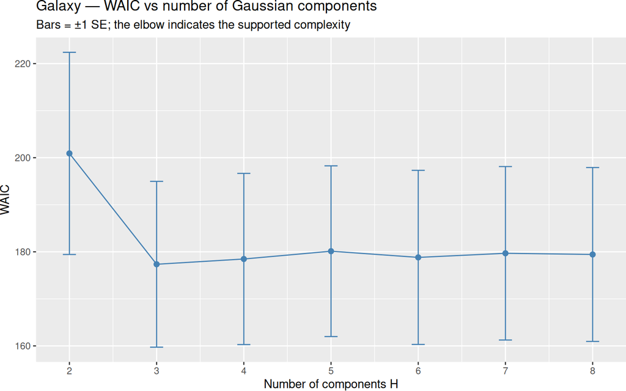

```r
gal_curve <- bind_rows(Map(function(w, nm)
  data.frame(H = as.integer(sub("H=", "", nm)),
             WAIC = w$estimates["waic", "Estimate"],
             SE   = w$estimates["waic", "SE"]),
  gal_waic, names(gal_waic)))

ggplot(gal_curve, aes(H, WAIC)) +
  geom_line(colour = "steelblue") +
  geom_point(size = 2, colour = "steelblue") +
  geom_errorbar(aes(ymin = WAIC - SE, ymax = WAIC + SE),
                width = 0.15, colour = "steelblue") +
  scale_x_continuous(breaks = H_grid) +
  labs(title    = "Galaxy — WAIC vs number of Gaussian components",
       subtitle = "Bars = ±1 SE; the elbow indicates the supported complexity",
       x = "Number of components H", y = "WAIC")
```

**How to read the WAIC-vs-$H$ curve.** The general shape we expect is a “hockey stick”: as we add components from $H = 2$ upwards the in-sample fit improves rapidly, WAIC drops steeply, and we are clearly under-fitting the data. At some value of $H$ the curve flattens — adding more components only buys us flexibility to fit noise, the effective-parameter penalty `p_eff` rises to compensate, and WAIC stops decreasing (or even rises). The location of this *elbow* is the supported complexity of the data.

Below we extract the WAIC-best model and plot its posterior predictive density for comparison with the $H = 6$ fit above.

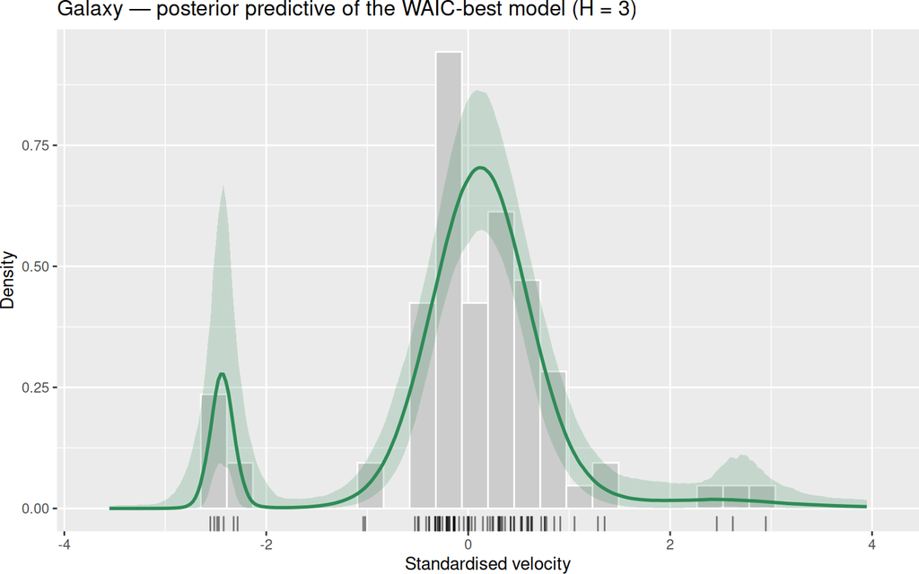

```r
H_best   <- gal_curve$H[which.min(gal_curve$WAIC)]
fit_best <- gal_fits[[paste0("H=", H_best)]]
ppd_best <- ppd_gauss(as.matrix(fit_best), H_best, x_grid)

ggplot() +
  geom_histogram(data = data.frame(y = data_gal),
                 aes(y, after_stat(density)), bins = 30,
                 fill = "grey80", colour = "white") +
  geom_ribbon(data = ppd_best, aes(x, ymin = lo, ymax = hi),
              fill = "seagreen", alpha = 0.2) +
  geom_line(data = ppd_best, aes(x, med), colour = "seagreen", linewidth = 1) +
  geom_rug(data = data.frame(y = data_gal), aes(y), sides = "b", alpha = 0.5) +
  labs(title    = paste0("Galaxy — posterior predictive of the WAIC-best model (H = ",
                         H_best, ")"),
       x = "Standardised velocity", y = "Density")
```

# Example 3: a real-world case study with Beta mixtures — fossil-fuel shares in 2015 vs 2024

We close the lecture with a serious application of Bayesian mixture modelling to a real, slightly contentious empirical question. Up to now every component has been Gaussian; here, the data live on the unit interval $[0,1]$ and call for a different component family — the **Beta distribution**. Apart from that one change, the mechanics of the analysis are identical to Example 2: latent allocation, the `fit_mixture` helper, post-hoc relabelling by component mean, and posterior predictive density. We fix the number of components in advance rather than selecting it, so the `log_lik[i]` machinery is not needed in this example.

For each country in the world we have, in each year, the **share of total primary energy that comes from fossil fuels** — coal, oil and gas combined. This is a proportion in $[0,1]$, and the world-wide distribution of this proportion across countries is the central object of the study. We focus on two years, **2015** and **2024**, and ask a simple but loaded question:

> Has the global energy mix really moved away from fossil fuels in the last decade, and is the move visible *in every group of countries*, or only in some?

The case study is built around a comparison of **three ways of looking at the same two-year dataset**, in increasing order of sophistication:

1. **The empirical mean** — just compute the average fossil-fuel share each year and compare.
2. **A single Beta per year** — fit one Beta distribution to each year’s country-level shares and compare the fitted densities. We use this view to *introduce the Beta distribution itself*.
3. **A Beta mixture per year** — the full analysis, which extends the single Beta to a mixture, exactly as Example 2 extended a single Gaussian.

The argument we will make — and verify with the data — is that the first two views look reasonable but are **systematically misleading** for this dataset, because the population of countries is *not homogeneous*. There is a heavy-fossil-fuel group near $1$, a middle group in the $0.7\text{–}0.9$ range, and a clean group below $0.5$, and any analysis that collapses these into a single average or a single Beta will hide exactly what we want to see: *which* of these groups is moving, and *how*.

## The data

The CSV file `fossil-fuels-share-energy.csv` is a long-format table with one row per (country, year). We pull out 2015 and 2024, divide the share by $100$ to bring it into $(0, 1)$, and trim a hair away from the open endpoints — a Beta likelihood evaluates $\log x$ and $\log(1-x)$, so we cannot afford exact $0$ or $1$ values.

```r
ff <- read.csv("fossil-fuels-share-energy.csv")

# Keep only 2015 and 2024, transform percent -> open unit interval.
yrs <- c(2015, 2024)
ff_yrs <- ff %>%
  filter(Year %in% yrs) %>%
  mutate(share = `Fossil.fuels` / 100,
         share = pmin(pmax(share, 1e-4), 1 - 1e-4))

df_2015 <- ff_yrs %>% filter(Year == 2015)
df_2024 <- ff_yrs %>% filter(Year == 2024)

y_2015       <- df_2015$share
y_2024       <- df_2024$share
country_2015 <- df_2015$Entity     # in the same order as y_2015
country_2024 <- df_2024$Entity     # in the same order as y_2024

c(n_2015 = length(y_2015), n_2024 = length(y_2024))
```

```
## n_2015 n_2024
##     79     79
```

A first look at the two histograms side by side already tells a story.

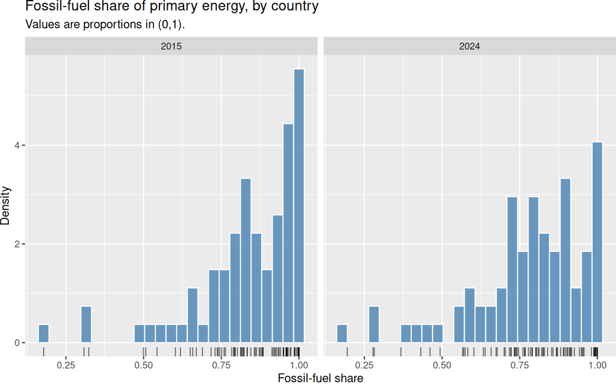

```r
ggplot(ff_yrs, aes(x = share)) +
  geom_histogram(aes(y = after_stat(density)),
                 bins = 25, fill = "steelblue", colour = "white", alpha = 0.8) +
  geom_rug(sides = "b", alpha = 0.5) +
  facet_wrap(~ Year) +
  labs(title = "Fossil-fuel share of primary energy, by country",
       subtitle = "Values are proportions in (0,1).",
       x = "Fossil-fuel share", y = "Density")
```

Both years are clearly **multimodal**: a tall pile near $1$ (countries almost entirely powered by fossil fuels), a broad bump in the middle, and a thinner group on the left. Visually the 2024 histogram looks slightly less extreme on the right — but the eye is a notoriously unreliable instrument, and the question is exactly *how much* of the change is real and where it sits.

## View 1: just the empirical means

The simplest possible comparison is to compute the average share in each year.

```r
data.frame(
  Year = c(2015, 2024),
  mean_share = round(c(mean(y_2015), mean(y_2024)), 4),
  median_share = round(c(median(y_2015), median(y_2024)), 4),
  sd_share = round(c(sd(y_2015), sd(y_2024)), 4)
)
```

| Year | mean_share | median_share | sd_share |
| --- | --- | --- | --- |
| 2015 | 0.8366 | 0.8749 | 0.1692 |
| 2024 | 0.7847 | 0.8093 | 0.1806 |

The mean has dropped by roughly five percentage points, and the median by a similar amount. That is a real movement, and a reader presented with only this number would correctly conclude that *something* shifted between 2015 and 2024 — but they would have no way to say *what*. The mean **summarises an entire heterogeneous population with a single number**, so it cannot tell us whether the drop is the clean countries getting cleaner, the dirty countries getting cleaner, or some redistribution between them. The same five-point drop in the mean is compatible with very different stories about the world, and a single summary statistic does not allow us to choose between them.

## View 2: a single Beta per year

A slightly less crude approach is to fit a parametric distribution. The data live on $(0,1)$, so the natural one-shot choice is the **Beta distribution**,

$$f(x \mid \alpha, \beta) \;=\;
\frac{x^{\alpha-1}(1-x)^{\beta-1}}{B(\alpha, \beta)},
\qquad x \in (0, 1),\ \alpha, \beta > 0,$$

with $B(\alpha, \beta) = \Gamma(\alpha)\Gamma(\beta)/\Gamma(\alpha+\beta)$. A single Beta is already remarkably flexible — depending on $(\alpha, \beta)$ its shape can be flat, bell-shaped, J-shaped or U-shaped — but it is always unimodal (or, in the U-shape case, bimodal with the modes pinned at $0$ and $1$). It cannot have *interior* multiple modes, which is exactly why it will struggle on our multimodal data.

We stay in the Bayesian framework and fit a one-component Beta model in JAGS with weakly-informative positive priors on the two shape parameters:

$$Y_i \;\overset{\text{iid}}{\sim}\; \text{Beta}(\alpha, \beta),
\qquad \alpha, \beta \sim \text{Gamma}(1, 0.1).$$

The $\text{Gamma}(1, 0.1)$ prior has mean $10$ and a generous spread, so it allows the model to find both sharp components ($\alpha + \beta$ large) and broad ones, while keeping the parameters firmly positive.

```r
model_single_beta <- "
model {
  for (i in 1:N) {
    y[i] ~ dbeta(alpha, beta)
  }
  alpha ~ dgamma(1, 0.1)
  beta  ~ dgamma(1, 0.1)
  cmean <- alpha / (alpha + beta)
}
"

fit_single_beta <- function(y) {
  dl <- list(y = y, N = length(y))
  m  <- jags.model(textConnection(model_single_beta), data = dl,
                   n.chains = 3, n.adapt = 1000, quiet = TRUE)
  update(m, n.iter = 2000)
  as.matrix(coda.samples(m, c("alpha", "beta", "cmean"),
                         n.iter = 4000, thin = 4))
}

sb_2015 <- fit_single_beta(y_2015)
sb_2024 <- fit_single_beta(y_2024)

rbind(`2015` = round(colMeans(sb_2015), 3),
      `2024` = round(colMeans(sb_2024), 3))
```

```
##      alpha  beta cmean
## 2015 2.811 0.534 0.838
## 2024 2.823 0.747 0.789
```

We then form the **posterior predictive density** of the single Beta in the usual way — by evaluating $\text{Beta}(x \mid \alpha^{(t)}, \beta^{(t)})$ on a grid at each iteration and averaging across draws — and overlay it on the histogram with a 95% credible band.

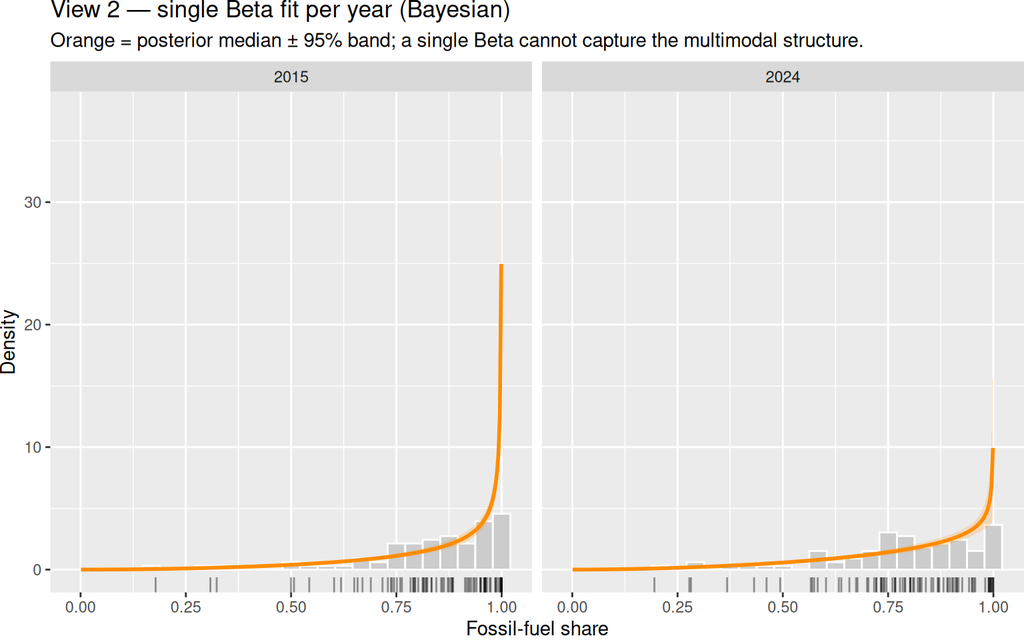

```r
xb_grid <- seq(0.001, 0.999, length.out = 300)

ppd_single_beta <- function(samp, x_grid) {
  dens <- sapply(seq_len(nrow(samp)), function(j)
    dbeta(x_grid, samp[j, "alpha"], samp[j, "beta"]))
  data.frame(x   = x_grid,
             med = apply(dens, 1, median),
             lo  = apply(dens, 1, quantile, 0.025),
             hi  = apply(dens, 1, quantile, 0.975))
}

sb_ppd <- bind_rows(
  cbind(ppd_single_beta(sb_2015, xb_grid), Year = 2015),
  cbind(ppd_single_beta(sb_2024, xb_grid), Year = 2024)
)

ggplot() +
  geom_histogram(data = ff_yrs,
                 aes(x = share, y = after_stat(density)), bins = 25,
                 fill = "grey80", colour = "white") +
  geom_ribbon(data = sb_ppd, aes(x = x, ymin = lo, ymax = hi),
              fill = "darkorange", alpha = 0.2) +
  geom_line(data = sb_ppd, aes(x = x, y = med),
            colour = "darkorange", linewidth = 1) +
  geom_rug(data = ff_yrs, aes(x = share), sides = "b", alpha = 0.4) +
  facet_wrap(~ Year) +
  labs(title    = "View 2 — single Beta fit per year (Bayesian)",
       subtitle = "Orange = posterior median ± 95% band; a single Beta cannot capture the multimodal structure.",
       x = "Fossil-fuel share", y = "Density")
```

The single-Beta fit is **J-shaped**, climbing monotonically from near zero on the left up to a spike at the right boundary — the posterior of $\beta$ is concentrated below $1$ in both years, which produces exactly this kind of singularity near $1$. The fit captures the *gross* fact that most of the data sit to the right, but it has no notion of the distinct middle bump that the data so clearly show, and it certainly cannot represent the thin left tail of low-fossil-fuel countries: it puts essentially zero density there. The two year-specific Betas differ slightly in how peaked their right-boundary spike is, mirroring the small movement in the mean, and that is the *only* thing they can tell us. **A single Beta is structurally incapable of giving us a cluster-by-cluster story**, because it has no clusters.

## View 3: a Beta mixture per year

To get *interior* multimodality, or to combine several distinct populations on $[0,1]$, we extend the single Beta to a **finite Beta mixture**,

$$f(x) \;=\; \sum_{h=1}^{H} p_h\, \text{Beta}(x \mid \alpha_h, \beta_h),$$

with mixing weights $(p_1, \dots, p_H)$ on the simplex. This is the same construction as the Gaussian mixture of Example 2 — only the per-component family changes. Writing the model in latent-allocation form,

$$Y_i \mid Z_i = z_i \sim \text{Beta}(\alpha_{z_i}, \beta_{z_i}),
\quad Z_i \mid p \sim \mathcal{C}at(p),
\quad p \sim \text{Dirichlet}(1, \dots, 1),$$

with $\alpha_h, \beta_h \sim \text{Gamma}(1, 0.1)$ as in View 2.

The translation to JAGS is **structurally identical** to the Gaussian galaxy model of Example 2 — same latent-allocation likelihood, same Dirichlet prior on the weights — with one substantive change (`dbeta` in place of `dnorm`) and one omission. The omission is the `log_lik[i]` block that we used in the galaxy example to feed WAIC: here we are **not** going to do model selection across different values of $H$ — we fix $H = 3$ by inspection — so there is no reason to compute or monitor the pointwise log-likelihood. As a general rule, **compute `log_lik[i]` only when you plan to use it**; otherwise the JAGS model can stay simple.

We do pre-compute the **component mean** $\alpha_h/(\alpha_h+\beta_h)$ inside the model as `cmean[h]`, since for the Beta distribution this is the natural quantity to relabel by.

```r
model_beta_mix <- "
model {

  # Latent-allocation likelihood
  for (i in 1:N) {
    z[i] ~ dcat(p[])
    y[i] ~ dbeta(alpha[z[i]], beta[z[i]])
  }

  # Priors on the component shapes
  for (h in 1:H) {
    alpha[h] ~ dgamma(1, 0.1)
    beta[h]  ~ dgamma(1, 0.1)
    cmean[h] <- alpha[h] / (alpha[h] + beta[h])   # component mean (for reporting)
  }

  # Dirichlet prior on the weights
  p[1:H] ~ ddirich(a[])
}
"
```

We use the **same number of components $H = 3$ in both years** — this is what makes the cluster-by-cluster comparison meaningful, because “the lowest-mean cluster in 2015” corresponds to “the lowest-mean cluster in 2024” after relabelling. Three components is what the histogram suggests by eye; one could in principle run the WAIC sweep from the galaxy example to confirm, but to keep the comparison clean we fix $H$ a priori.

```r
H <- 3
```

```r
dataList_2015 <- list(y = y_2015, N = length(y_2015), H = H, a = rep(1, H))

samples_2015 <- fit_mixture(
  model_beta_mix, dataList_2015,
  variable.names = c("alpha", "beta", "p", "cmean"),
  burn = 6000, n.iter = 12000, thin = 6, n.chains = 3, n.adapt = 3000
)
```

```r
dataList_2024 <- list(y = y_2024, N = length(y_2024), H = H, a = rep(1, H))

samples_2024 <- fit_mixture(
  model_beta_mix, dataList_2024,
  variable.names = c("alpha", "beta", "p", "cmean"),
  burn = 6000, n.iter = 12000, thin = 6, n.chains = 3, n.adapt = 3000
)
```

### Relabel by increasing component mean

Components are exchangeable, so we relabel each posterior draw by increasing $\texttt{cmean}[h]$, exactly as we did for the Gaussian galaxy mixture. After relabelling, **component $h$ has the same meaning across years**: $h = 1$ is the lowest-mean cluster, $h = 3$ is the highest-mean cluster. *That* is what we will compare.

```r
a_cols  <- paste0("alpha[", 1:H, "]")
b_cols  <- paste0("beta[",  1:H, "]")
p_cols  <- paste0("p[",     1:H, "]")
cm_cols <- paste0("cmean[", 1:H, "]")

mat_2015 <- as.matrix(samples_2015)
mat_2024 <- as.matrix(samples_2024)

mat_2015_rl <- relabel_by(mat_2015, H, key_cols = cm_cols,
                          move_groups = list(a_cols, b_cols, p_cols, cm_cols))
mat_2024_rl <- relabel_by(mat_2024, H, key_cols = cm_cols,
                          move_groups = list(a_cols, b_cols, p_cols, cm_cols))
```

### Posterior predictive density of the mixture

This is the same picture as for the Gaussian galaxy mixture: the posterior predictive density of the total mixture, with a 95% credible band, overlaid on the histogram. We package the evaluator as a small `ppd_beta` helper — structurally identical to `ppd_gauss` from Example 2, only the per-component density changes.

```r
# Posterior predictive of a Beta mixture from a matrix of draws.
ppd_beta <- function(samp_mat, H, x_grid, n_draws = 1000) {
  a_cols <- paste0("alpha[", 1:H, "]")
  b_cols <- paste0("beta[",  1:H, "]")
  p_cols <- paste0("p[",     1:H, "]")
  idx <- sample(nrow(samp_mat), min(n_draws, nrow(samp_mat)))
  dens <- sapply(idx, function(j) {
    a_j <- samp_mat[j, a_cols]; b_j <- samp_mat[j, b_cols]
    p_j <- samp_mat[j, p_cols]
    rowSums(sapply(1:H, function(h) p_j[h] * dbeta(x_grid, a_j[h], b_j[h])))
  })
  data.frame(x   = x_grid,
             med = apply(dens, 1, median),
             lo  = apply(dens, 1, quantile, 0.025),
             hi  = apply(dens, 1, quantile, 0.975))
}
```

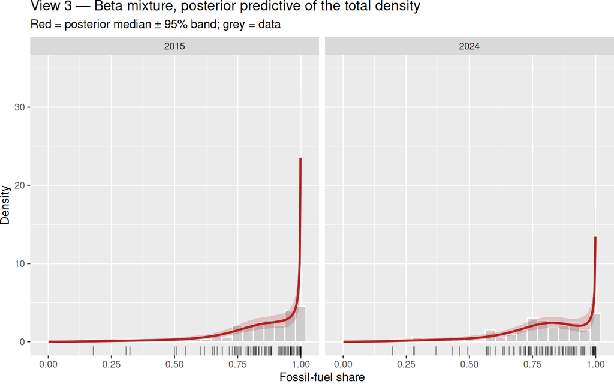

```r
ppd_2015 <- ppd_beta(mat_2015, H, xb_grid)
ppd_2024 <- ppd_beta(mat_2024, H, xb_grid)

ppd_2015$Year <- 2015
ppd_2024$Year <- 2024
ppd_both <- rbind(ppd_2015, ppd_2024)

ggplot() +
  geom_histogram(data = ff_yrs,
                 aes(x = share, y = after_stat(density)), bins = 25,
                 fill = "grey80", colour = "white") +
  geom_ribbon(data = ppd_both, aes(x = x, ymin = lo, ymax = hi),
              fill = "firebrick", alpha = 0.2) +
  geom_line(data = ppd_both, aes(x = x, y = med),
            colour = "firebrick", linewidth = 1) +
  geom_rug(data = ff_yrs, aes(x = share), sides = "b", alpha = 0.4) +
  facet_wrap(~ Year) +
  labs(title    = "View 3 — Beta mixture, posterior predictive of the total density",
       subtitle = "Red = posterior median ± 95% band; grey = data",
       x = "Fossil-fuel share", y = "Density")
```

### Component-by-component view

The previous plot shows the *sum* of the three Beta components. To understand what each component looks like — and to confirm that the model has split the data into three substantively different sub-populations — we redraw the same plot but show the **three weighted components $p_h \cdot \text{Beta}(\alpha_h, \beta_h)$ separately**, each in its own colour, with its own posterior median and 95% credible band. The band shows the **uncertainty about each fitted component**, exactly as the red band in the previous plot showed the uncertainty about the total mixture. Adding the three coloured *medians* pointwise gives back the red curve from the previous plot.

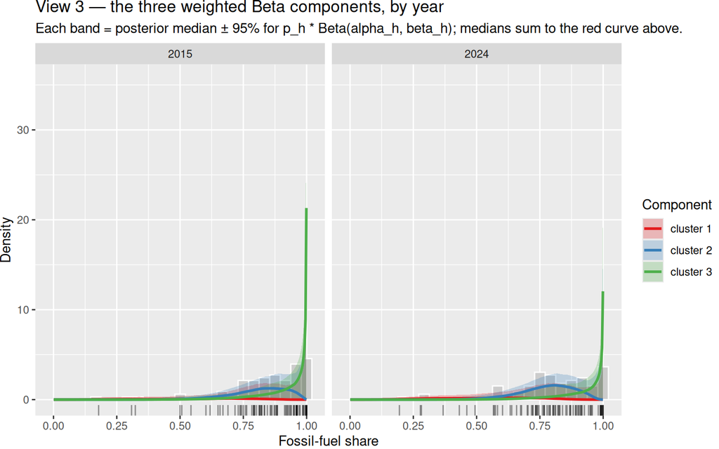

```r
# Posterior median + 95% band of each weighted component density, on the grid.
ppd_beta_components <- function(samp_mat, H, x_grid, n_draws = 1000) {
  a_cols <- paste0("alpha[", 1:H, "]")
  b_cols <- paste0("beta[",  1:H, "]")
  p_cols <- paste0("p[",     1:H, "]")
  idx <- sample(nrow(samp_mat), min(n_draws, nrow(samp_mat)))
  out <- vector("list", H)
  for (h in 1:H) {
    dens_h <- sapply(idx, function(j)
      samp_mat[j, p_cols[h]] *
        dbeta(x_grid, samp_mat[j, a_cols[h]], samp_mat[j, b_cols[h]]))
    out[[h]] <- data.frame(x         = x_grid,
                           med       = apply(dens_h, 1, median),
                           lo        = apply(dens_h, 1, quantile, 0.025),
                           hi        = apply(dens_h, 1, quantile, 0.975),
                           Component = paste0("cluster ", h))
  }
  do.call(rbind, out)
}

comp_2015 <- ppd_beta_components(mat_2015_rl, H, xb_grid)
comp_2024 <- ppd_beta_components(mat_2024_rl, H, xb_grid)
comp_2015$Year <- 2015
comp_2024$Year <- 2024
comp_both <- rbind(comp_2015, comp_2024)

ggplot() +
  geom_histogram(data = ff_yrs,
                 aes(x = share, y = after_stat(density)), bins = 25,
                 fill = "grey80", colour = "white") +
  geom_ribbon(data = comp_both,
              aes(x = x, ymin = lo, ymax = hi, fill = Component),
              alpha = 0.25, colour = NA) +
  geom_line(data = comp_both,
            aes(x = x, y = med, colour = Component),
            linewidth = 1) +
  geom_rug(data = ff_yrs, aes(x = share), sides = "b", alpha = 0.4) +
  facet_wrap(~ Year) +
  scale_colour_brewer(palette = "Set1") +
  scale_fill_brewer(palette = "Set1") +
  labs(title    = "View 3 — the three weighted Beta components, by year",
       subtitle = "Each band = posterior median ± 95% for p_h * Beta(alpha_h, beta_h); medians sum to the red curve above.",
       x = "Fossil-fuel share", y = "Density")
```

The six curves (three components × two years) make the structure of the problem visible at a glance: each year has a “clean” cluster (cluster 1) on the left, a “middle” cluster (cluster 2) centred in the $0.7\text{–}0.8$ range, and a “dirty” cluster (cluster 3) piled up near $1$. The middle cluster in 2024 is *visibly* taller than in 2015, and the dirty cluster in 2024 is shorter — i.e. fewer countries now belong to the heaviest-fossil-fuel group and more belong to the middle group. **This is the kind of compositional shift that the mean and the single-Beta fit cannot show.**

### Cluster mean comparison

We can now quantify what the plot suggests. For each component $h$ we report the posterior mean of $\mu^{2015}_h = \alpha^{2015}_h / (\alpha^{2015}_h + \beta^{2015}_h)$ and of $\mu^{2024}_h$, with $95\%$ credible intervals.

```r
summarise_cmean <- function(mat_rl, label) {
  tab <- t(apply(mat_rl[, cm_cols], 2, function(x)
    c(mean = mean(x), sd = sd(x),
      `2.5%` = quantile(x, .025), `97.5%` = quantile(x, .975))))
  rownames(tab) <- paste0("cluster ", 1:H, " (", label, ")")
  round(tab, 4)
}

rbind(summarise_cmean(mat_2015_rl, "2015"),
      summarise_cmean(mat_2024_rl, "2024"))
```

```
##                    mean     sd 2.5%.2.5% 97.5%.97.5%
## cluster 1 (2015) 0.5453 0.2211    0.1505      0.8247
## cluster 2 (2015) 0.8130 0.0422    0.7345      0.8791
## cluster 3 (2015) 0.9079 0.0463    0.8291      0.9849
## cluster 1 (2024) 0.5477 0.1751    0.2257      0.7802
## cluster 2 (2024) 0.7777 0.0331    0.7123      0.8416
## cluster 3 (2024) 0.8904 0.0639    0.7818      0.9854
```

The two posteriors are **independent** (we ran two separate JAGS fits on two separate datasets), so we can simply pair up draws iteration by iteration: at iteration $t$ we have a triple of cluster means $\mu^{2015,(t)}_{1:3}$ and another triple $\mu^{2024,(t)}_{1:3}$, and for each iteration we can ask, as a yes/no question, whether *all three* cluster means dropped from 2015 to 2024.

```r
T_use      <- min(nrow(mat_2015_rl), nrow(mat_2024_rl))
cm_15      <- mat_2015_rl[seq_len(T_use), cm_cols, drop = FALSE]
cm_24      <- mat_2024_rl[seq_len(T_use), cm_cols, drop = FALSE]
diff_24_15 <- cm_24 - cm_15
colnames(diff_24_15) <- paste0("delta_cluster_", 1:H)
```

Per-cluster probability that the 2024 mean is lower than the 2015 mean:

```r
per_cluster <- data.frame(
  Cluster        = paste0("cluster ", 1:H),
  mean_2015      = round(colMeans(cm_15), 4),
  mean_2024      = round(colMeans(cm_24), 4),
  mean_delta     = round(colMeans(diff_24_15), 4),
  `P(2024<2015)` = round(colMeans(diff_24_15 < 0), 3),
  `delta 2.5%`   = round(apply(diff_24_15, 2, quantile, 0.025), 4),
  `delta 97.5%`  = round(apply(diff_24_15, 2, quantile, 0.975), 4),
  check.names = FALSE
)
knitr::kable(per_cluster,
             caption = "Posterior comparison of cluster means, 2024 vs 2015. Negative delta means 2024 is lower.")
```

Posterior comparison of cluster means, 2024 vs 2015. Negative delta means 2024 is lower.

|  | Cluster | mean_2015 | mean_2024 | mean_delta | P(2024<2015) | delta 2.5% | delta 97.5% |
| --- | --- | --- | --- | --- | --- | --- | --- |
| cmean[1] | cluster 1 | 0.5453 | 0.5477 | 0.0024 | 0.514 | -0.5154 | 0.5234 |
| cmean[2] | cluster 2 | 0.8130 | 0.7777 | -0.0353 | 0.785 | -0.1321 | 0.0706 |
| cmean[3] | cluster 3 | 0.9079 | 0.8904 | -0.0174 | 0.577 | -0.1664 | 0.1231 |

The headline joint event — “*every* cluster’s mean is lower in 2024 than in 2015” — is the intersection $\bigcap_{h=1}^{3} \{\mu^{2024}_h < \mu^{2015}_h\}$:

```r
all_lower      <- rowSums(diff_24_15 < 0) == H
prob_all_lower <- mean(all_lower)
cat(sprintf(
  "Posterior probability that the mean of *every* cluster is lower in 2024 than in 2015:\n  P = %.3f  (out of %d paired draws)\n",
  prob_all_lower, T_use))
```

```
## Posterior probability that the mean of *every* cluster is lower in 2024 than in 2015:
##   P = 0.269  (out of 6000 paired draws)
```

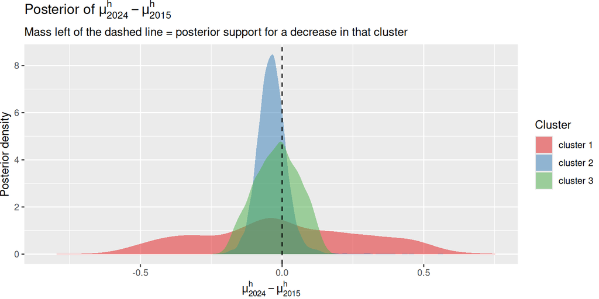

```r
diff_long <- as.data.frame(diff_24_15) %>%
  pivot_longer(everything(), names_to = "Cluster", values_to = "delta") %>%
  mutate(Cluster = factor(Cluster,
                          levels = paste0("delta_cluster_", 1:H),
                          labels = paste0("cluster ", 1:H)))

ggplot(diff_long, aes(delta, fill = Cluster)) +
  geom_density(alpha = 0.5, colour = NA) +
  geom_vline(xintercept = 0, linetype = "dashed") +
  scale_fill_brewer(palette = "Set1") +
  labs(title    = expression("Posterior of "*mu[2024]^h - mu[2015]^h),
       subtitle = "Mass left of the dashed line = posterior support for a decrease in that cluster",
       x = expression(mu[2024]^h - mu[2015]^h), y = "Posterior density")
```

The means shift modestly and noisily, and the joint event is far from certain. On the level of cluster *means alone*, the evidence for a universal decarbonisation is weak — but the analysis is not over.

### How big is each cluster? (the mixing weights)

The cluster mean tells us *where* a cluster sits; the cluster weight $p_h$ tells us *how much of the population* belongs to it. A cluster could have a similar mean in both years but a much smaller weight — meaning fewer countries fit that description — and that is itself a substantive change.

```r
weights_2015 <- mat_2015_rl[, p_cols]
weights_2024 <- mat_2024_rl[, p_cols]

weight_summary <- data.frame(
  Cluster   = paste0("cluster ", 1:H),
  p_2015    = round(colMeans(weights_2015), 3),
  p_2015_lo = round(apply(weights_2015, 2, quantile, 0.025), 3),
  p_2015_hi = round(apply(weights_2015, 2, quantile, 0.975), 3),
  p_2024    = round(colMeans(weights_2024), 3),
  p_2024_lo = round(apply(weights_2024, 2, quantile, 0.025), 3),
  p_2024_hi = round(apply(weights_2024, 2, quantile, 0.975), 3)
)
knitr::kable(weight_summary,
             caption = "Posterior mixing weights with 95% credible intervals.")
```

Posterior mixing weights with 95% credible intervals.

|  | Cluster | p_2015 | p_2015_lo | p_2015_hi | p_2024 | p_2024_lo | p_2024_hi |
| --- | --- | --- | --- | --- | --- | --- | --- |
| p[1] | cluster 1 | 0.154 | 0.005 | 0.588 | 0.202 | 0.010 | 0.655 |
| p[2] | cluster 2 | 0.411 | 0.047 | 0.781 | 0.458 | 0.070 | 0.781 |
| p[3] | cluster 3 | 0.435 | 0.037 | 0.840 | 0.340 | 0.034 | 0.728 |

```r
w_15      <- mat_2015_rl[seq_len(T_use), p_cols, drop = FALSE]
w_24      <- mat_2024_rl[seq_len(T_use), p_cols, drop = FALSE]
diff_w    <- w_24 - w_15
prob_drop <- colMeans(diff_w < 0)

data.frame(Cluster          = paste0("cluster ", 1:H),
           mean_delta_p     = round(colMeans(diff_w), 3),
           `P(p2024<p2015)` = round(prob_drop, 3),
           check.names = FALSE)
```

|  | Cluster | mean_delta_p | P(p2024<p2015) |
| --- | --- | --- | --- |
| p[1] | cluster 1 | 0.048 | 0.392 |
| p[2] | cluster 2 | 0.047 | 0.426 |
| p[3] | cluster 3 | -0.095 | 0.633 |

### Which countries belong to which cluster?

The mixing weights describe the *population*, but we can also ask, for each individual country $i$, the **posterior probability that country $i$ belongs to cluster $h$**. This is the *responsibility* of cluster $h$ for country $i$,

$$\gamma_{ih} \;=\; P(z_i = h \mid y_i, \text{data})
\;=\; \mathbb E_{\theta \mid \text{data}}\!\left[
\frac{p_h\, \text{Beta}(y_i \mid \alpha_h, \beta_h)}{
\sum_{k=1}^{H} p_k\, \text{Beta}(y_i \mid \alpha_k, \beta_k)}
\right],$$

estimated by averaging the integrand over our posterior draws. The natural single label for country $i$ is the **MAP cluster** $\hat z_i = \arg\max_h \gamma_{ih}$.

```r
posterior_resp <- function(mat_rl, y, H) {
  a_cols <- paste0("alpha[", 1:H, "]")
  b_cols <- paste0("beta[",  1:H, "]")
  p_cols <- paste0("p[",     1:H, "]")
  N <- length(y); T <- nrow(mat_rl)
  resp_sum <- matrix(0, N, H)
  for (j in seq_len(T)) {
    a_j <- mat_rl[j, a_cols]; b_j <- mat_rl[j, b_cols]; p_j <- mat_rl[j, p_cols]
    dens <- sapply(1:H, function(h) p_j[h] * dbeta(y, a_j[h], b_j[h]))
    if (!is.matrix(dens)) dens <- matrix(dens, nrow = N)
    resp_sum <- resp_sum + dens / rowSums(dens)
  }
  resp_avg <- resp_sum / T
  colnames(resp_avg) <- paste0("cluster_", 1:H)
  resp_avg
}

resp_2015 <- posterior_resp(mat_2015_rl, y_2015, H)
resp_2024 <- posterior_resp(mat_2024_rl, y_2024, H)

assign_2015 <- max.col(resp_2015)
assign_2024 <- max.col(resp_2024)
```

How many countries are MAP-assigned to each cluster?

```r
counts <- data.frame(
  Cluster    = paste0("cluster ", 1:H),
  count_2015 = tabulate(assign_2015, nbins = H),
  count_2024 = tabulate(assign_2024, nbins = H),
  share_2015 = round(tabulate(assign_2015, nbins = H) / length(y_2015), 3),
  share_2024 = round(tabulate(assign_2024, nbins = H) / length(y_2024), 3)
)
knitr::kable(counts,
             caption = "MAP cluster counts and empirical shares, by year.")
```

MAP cluster counts and empirical shares, by year.

| Cluster | count_2015 | count_2024 | share_2015 | share_2024 |
| --- | --- | --- | --- | --- |
| cluster 1 | 3 | 7 | 0.038 | 0.089 |
| cluster 2 | 41 | 53 | 0.519 | 0.671 |
| cluster 3 | 35 | 19 | 0.443 | 0.241 |

And the country lists themselves, sorted by fossil-fuel share within each cluster (lowest first):

```r
print_lists <- function(country, share, assign, H, year) {
  cat("============== Year:", year, "==============\n")
  for (h in 1:H) {
    in_h <- which(assign == h)
    if (length(in_h) == 0) {
      cat(sprintf("\n--- Cluster %d (empty) ---\n", h)); next
    }
    o <- order(share[in_h])
    cat(sprintf("\n--- Cluster %d  (n = %d) ---\n", h, length(in_h)))
    for (k in in_h[o]) {
      cat(sprintf("  %-25s  %.3f\n", country[k], share[k]))
    }
  }
  cat("\n")
}

print_lists(country_2015, y_2015, assign_2015, H, 2015)
```

```
## ============== Year: 2015 ==============
##
## --- Cluster 1  (n = 3) ---
##   Iceland                    0.178
##   Sweden                     0.308
##   Norway                     0.323
##
## --- Cluster 2  (n = 41) ---
##   Switzerland                0.500
##   France                     0.507
##   Finland                    0.543
##   Brazil                     0.602
##   New Zealand                0.619
##   Slovenia                   0.650
##   Canada                     0.658
##   Austria                    0.669
##   Slovakia                   0.689
##   Bulgaria                   0.717
##   Denmark                    0.730
##   Spain                      0.737
##   Romania                    0.740
##   Colombia                   0.745
##   Peru                       0.751
##   Ukraine                    0.759
##   Portugal                   0.763
##   Croatia                    0.783
##   Chile                      0.790
##   Czechia                    0.790
##   Hungary                    0.794
##   Germany                    0.795
##   Venezuela                  0.802
##   Ecuador                    0.812
##   Latvia                     0.813
##   United Kingdom             0.816
##   Sri Lanka                  0.819
##   Vietnam                    0.822
##   North Macedonia            0.823
##   Italy                      0.833
##   Belgium                    0.833
##   United States              0.845
```

[output cut: 31 more lines]

```
##   Iran                       0.984
##   Iraq                       0.986
##   Israel                     0.987
##   Bangladesh                 0.992
##   Belarus                    0.997
##   Singapore                  0.997
##   Hong Kong                  0.998
##   Algeria                    0.999
##   Qatar                      0.999
##   United Arab Emirates       0.999
##   Kuwait                     1.000
##   Oman                       1.000
##   Saudi Arabia               1.000
##   Trinidad and Tobago        1.000
##   Turkmenistan               1.000
```

```r
print_lists(country_2024, y_2024, assign_2024, H, 2024)
```

```
## ============== Year: 2024 ==============
##
## --- Cluster 1  (n = 7) ---
##   Iceland                    0.195
##   Sweden                     0.278
##   Norway                     0.282
##   Finland                    0.368
##   Switzerland                0.432
##   France                     0.461
##   Brazil                     0.494
##
## --- Cluster 2  (n = 53) ---
##   Austria                    0.567
##   Slovenia                   0.570
##   New Zealand                0.574
##   Denmark                    0.583
##   Portugal                   0.603
##   Bulgaria                   0.633
##   Slovakia                   0.639
##   Spain                      0.658
##   Canada                     0.674
##   Chile                      0.677
##   Ukraine                    0.700
##   Latvia                     0.703
##   Czechia                    0.717
##   Hungary                    0.722
##   Croatia                    0.722
##   Romania                    0.733
##   Peru                       0.733
##   United Kingdom             0.735
##   Colombia                   0.739
##   Venezuela                  0.742
##   Ecuador                    0.746
##   Germany                    0.760
##   Lithuania                  0.766
##   Belgium                    0.766
##   Sri Lanka                  0.768
##   Ireland                    0.778
##   Vietnam                    0.785
##   Greece                     0.789
```

[output cut: 31 more lines]

```
##   South Africa               0.950
##   Uzbekistan                 0.954
##   Azerbaijan                 0.957
##   Iran                       0.981
##   Oman                       0.989
##   Bangladesh                 0.989
##   Hong Kong                  0.990
##   Qatar                      0.992
##   Saudi Arabia               0.993
##   Iraq                       0.994
##   Singapore                  0.995
##   Algeria                    0.998
##   Kuwait                     0.999
##   Trinidad and Tobago        1.000
##   Turkmenistan               1.000
```

### Who moved cluster?

Now the most interpretive question. Which countries *changed* MAP cluster between 2015 and 2024? We restrict to countries that appear in both years (here all 79) and report only the ones whose label changed.

```r
common <- intersect(country_2015, country_2024)
idx15  <- match(common, country_2015)
idx24  <- match(common, country_2024)

panel <- tibble(
  Country      = common,
  share_2015   = round(y_2015[idx15], 3),
  share_2024   = round(y_2024[idx24], 3),
  cluster_2015 = assign_2015[idx15],
  cluster_2024 = assign_2024[idx24]
) %>%
  mutate(direction = case_when(
    cluster_2024 <  cluster_2015 ~ "down (cleaner cluster)",
    cluster_2024 >  cluster_2015 ~ "up (dirtier cluster)",
    TRUE                         ~ "same"))

movers <- panel %>% filter(cluster_2015 != cluster_2024) %>%
  arrange(direction, Country)

knitr::kable(movers,
             caption = paste0("Countries whose MAP cluster changed between ",
                              "2015 and 2024. Cluster 1 = lowest fossil-fuel ",
                              "share, cluster ", H, " = highest."))
```

Countries whose MAP cluster changed between 2015 and 2024. Cluster 1 = lowest fossil-fuel share, cluster 3 = highest.

| Country | share_2015 | share_2024 | cluster_2015 | cluster_2024 | direction |
| --- | --- | --- | --- | --- | --- |
| Australia | 0.940 | 0.853 | 3 | 2 | down (cleaner cluster) |
| Belarus | 0.997 | 0.868 | 3 | 2 | down (cleaner cluster) |
| Brazil | 0.602 | 0.494 | 2 | 1 | down (cleaner cluster) |
| Cyprus | 0.960 | 0.892 | 3 | 2 | down (cleaner cluster) |
| Estonia | 0.933 | 0.821 | 3 | 2 | down (cleaner cluster) |
| Finland | 0.543 | 0.368 | 2 | 1 | down (cleaner cluster) |
| France | 0.507 | 0.461 | 2 | 1 | down (cleaner cluster) |
| India | 0.924 | 0.897 | 3 | 2 | down (cleaner cluster) |
| Indonesia | 0.960 | 0.890 | 3 | 2 | down (cleaner cluster) |
| Israel | 0.987 | 0.902 | 3 | 2 | down (cleaner cluster) |
| Japan | 0.921 | 0.830 | 3 | 2 | down (cleaner cluster) |
| Lithuania | 0.917 | 0.766 | 3 | 2 | down (cleaner cluster) |
| Luxembourg | 0.951 | 0.857 | 3 | 2 | down (cleaner cluster) |
| Mexico | 0.928 | 0.904 | 3 | 2 | down (cleaner cluster) |
| Morocco | 0.949 | 0.913 | 3 | 2 | down (cleaner cluster) |
| Netherlands | 0.950 | 0.809 | 3 | 2 | down (cleaner cluster) |
| Poland | 0.936 | 0.870 | 3 | 2 | down (cleaner cluster) |
| Switzerland | 0.500 | 0.432 | 2 | 1 | down (cleaner cluster) |
| Taiwan | 0.913 | 0.914 | 3 | 2 | down (cleaner cluster) |
| United Arab Emirates | 0.999 | 0.910 | 3 | 2 | down (cleaner cluster) |

The compact summary is the **transition matrix** — rows are 2015 clusters, columns are 2024 clusters, the diagonal counts countries that stayed put.

```r
trans_mat <- table(`2015` = paste0("2015 cluster ", panel$cluster_2015),
                   `2024` = paste0("2024 cluster ", panel$cluster_2024))
knitr::kable(as.data.frame.matrix(trans_mat),
             caption = "Transition matrix of MAP cluster between 2015 and 2024.")
```

Transition matrix of MAP cluster between 2015 and 2024.

|  | 2024 cluster 1 | 2024 cluster 2 | 2024 cluster 3 |
| --- | --- | --- | --- |
| 2015 cluster 1 | 3 | 0 | 0 |
| 2015 cluster 2 | 4 | 37 | 0 |
| 2015 cluster 3 | 0 | 16 | 19 |

```r
cat(sprintf("Out of %d countries, %d changed cluster (%d down, %d up).\n",
            nrow(panel),
            sum(panel$cluster_2015 != panel$cluster_2024),
            sum(panel$cluster_2024 <  panel$cluster_2015),
            sum(panel$cluster_2024 >  panel$cluster_2015)))
```

```
## Out of 79 countries, 20 changed cluster (20 down, 0 up).
```

## The point of the case study

This is the broader pedagogical message of the lecture: a mixture model is not an exotic tool to be deployed in special cases. It is the *natural* model whenever a population is plausibly heterogeneous, and aggregating away that heterogeneity — by taking a mean, by fitting a single distribution — destroys exactly the information you want to recover.